# HW3 Combined

# Problem 1

1. This problem involves examination of monthly Lydia Pinkham data for the period 1938 through 1952. It addresses model construction and estimation of the 90 per cent duration interval. The data are in Lydiamonthly.txt.

```r
m.sales <- read.csv("Lydiamonthly.txt")

Time <- seq(1, nrow(m.sales))
fMonth<-as.factor(m.sales$month)
logmsales <- log(m.sales$msales)

m.sales<-data.frame(m.sales, Time, fMonth, logmsales)

attach(m.sales)
```

1. Construct a model relating sales and advertising with sales as the response. Explore the inclusion of lagged sales and lagged advertising variables. Include estimation of seasonal structure, dummies for outliers, and necessary calendar variables. Describe your fitted model.

## Problem 1.a.1

Construct a model relating sales and advertising with sales as the response.

**Discussion:** An initial inspection of model1 suggests that AR3 model is a good place to start.

```r
model1<-lm(msales~madv)
summary(model1)
```

```
##
## Call:
## lm(formula = msales ~ madv)
##
## Residuals:
##    Min     1Q Median     3Q    Max
## -58909 -20194  -6041  20867 108816
##
## Coefficients:
##              Estimate Std. Error t value Pr(>|t|)
## (Intercept) 1.212e+05  5.261e+03  23.041   <2e-16 ***
## madv        5.901e-01  5.939e-02   9.935   <2e-16 ***
## ---
## Signif. codes:  0 '***' 0.001 '**' 0.01 '*' 0.05 '.' 0.1 ' ' 1
##
## Residual standard error: 31370 on 178 degrees of freedom
## Multiple R-squared:  0.3567, Adjusted R-squared:  0.3531
## F-statistic: 98.71 on 1 and 178 DF,  p-value: < 2.2e-16
```

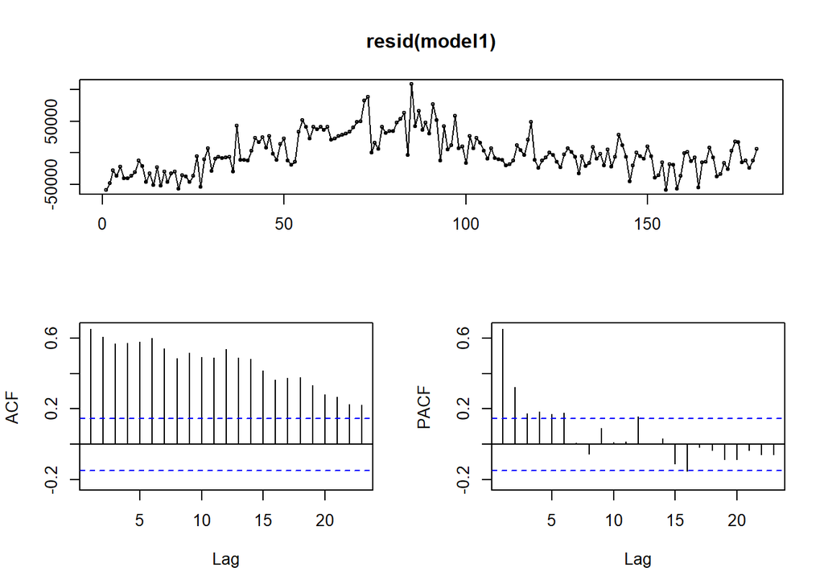

```r
forecast::tsdisplay(resid(model1))
```

## Problem 1.a.2

Explore the inclusion of lagged sales and lagged advertising variables. Include estimation of seasonal structure, dummies for outliers, and necessary calendar variables. Describe your fitted model.

**Discussion:** First we fit an AR(3) model with the inclusion of following X variables: advertising, lagged advertising, all dummy fmonth variables, all dummy outlier variables, and all calendar pairs.

We now discuss the significance of the variables.

The fMonth dummy variables seem to be significant, will have to conduct a partial f-test to confirm this. Some of the calendar pairs do not seem to be significant and we have to individually inspect their significance through partial f-test. All the outliers seem to be significant, so we will keep them.

```r
model2 <- lm(msales~madv+madvl1+madvl2+madvl3+madvl4+msalesl1+msalesl2+msalesl3+fMonth+feb44+dec44+jan45+sep45+c220+s220+c348+s348+c432+s432)

summary(model2)
```

```
##
## Call:
## lm(formula = msales ~ madv + madvl1 + madvl2 + madvl3 + madvl4 +
##     msalesl1 + msalesl2 + msalesl3 + fMonth + feb44 + dec44 +
##     jan45 + sep45 + c220 + s220 + c348 + s348 + c432 + s432)
##
## Residuals:
##    Min     1Q Median     3Q    Max
## -31327  -9248      0   6825  39232
##
## Coefficients:
##               Estimate Std. Error t value Pr(>|t|)
## (Intercept)  2.286e+04  8.019e+03   2.851 0.004975 **
## madv         2.224e-01  4.394e-02   5.062 1.20e-06 ***
## madvl1       9.603e-02  4.878e-02   1.969 0.050831 .
## madvl2      -1.994e-02  4.888e-02  -0.408 0.683935
## madvl3      -2.701e-02  4.780e-02  -0.565 0.572910
## madvl4       1.863e-02  4.540e-02   0.410 0.682084
## msalesl1     4.580e-01  7.184e-02   6.375 2.13e-09 ***
## msalesl2     2.812e-01  7.414e-02   3.792 0.000216 ***
## msalesl3     1.140e-01  6.861e-02   1.662 0.098593 .
## fMonth2     -1.786e+04  8.200e+03  -2.178 0.030972 *
## fMonth3     -8.487e+03  8.715e+03  -0.974 0.331688
## fMonth4     -2.898e+04  7.563e+03  -3.832 0.000186 ***
## fMonth5     -2.879e+04  7.258e+03  -3.966 0.000113 ***
## fMonth6     -2.891e+04  6.076e+03  -4.757 4.58e-06 ***
## fMonth7     -1.100e+04  6.091e+03  -1.806 0.072957 .
## fMonth8     -1.228e+04  6.735e+03  -1.824 0.070171 .
## fMonth9     -7.649e+03  7.527e+03  -1.016 0.311183
## fMonth10    -3.829e+03  7.679e+03  -0.499 0.618732
## fMonth11    -4.764e+04  8.216e+03  -5.798 3.83e-08 ***
## fMonth12    -4.987e+04  6.990e+03  -7.135 3.86e-11 ***
## feb44       -4.314e+04  1.524e+04  -2.830 0.005289 **
## dec44       -5.426e+04  1.464e+04  -3.707 0.000294 ***
## jan45        7.683e+04  1.510e+04   5.089 1.06e-06 ***
## sep45       -4.385e+04  1.470e+04  -2.983 0.003328 **
## c220         3.371e+03  1.468e+03   2.296 0.023065 *
## s220         9.777e+02  1.509e+03   0.648 0.518115
## c348         6.544e+02  1.566e+03   0.418 0.676638
## s348        -3.798e+03  1.549e+03  -2.452 0.015354 *
## c432        -9.077e+02  1.519e+03  -0.598 0.551055
## s432         1.703e+02  1.476e+03   0.115 0.908284
## ---
## Signif. codes:  0 '***' 0.001 '**' 0.01 '*' 0.05 '.' 0.1 ' ' 1
##
## Residual standard error: 13550 on 150 degrees of freedom
## Multiple R-squared:  0.8988, Adjusted R-squared:  0.8793
## F-statistic: 45.95 on 29 and 150 DF,  p-value: < 2.2e-16
```

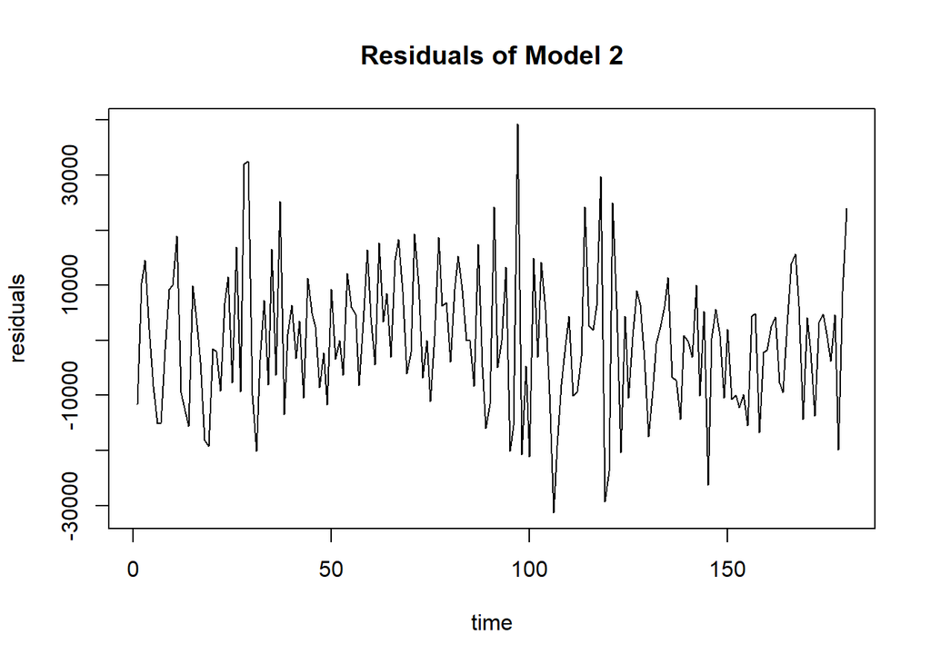

```r
res2 <- resid(model2)
resid2 <- ts(res2) #,start=c(1992,1),freq=12)
plot(resid2, xlab="time",ylab="residuals",main="Residuals of Model 2")
```

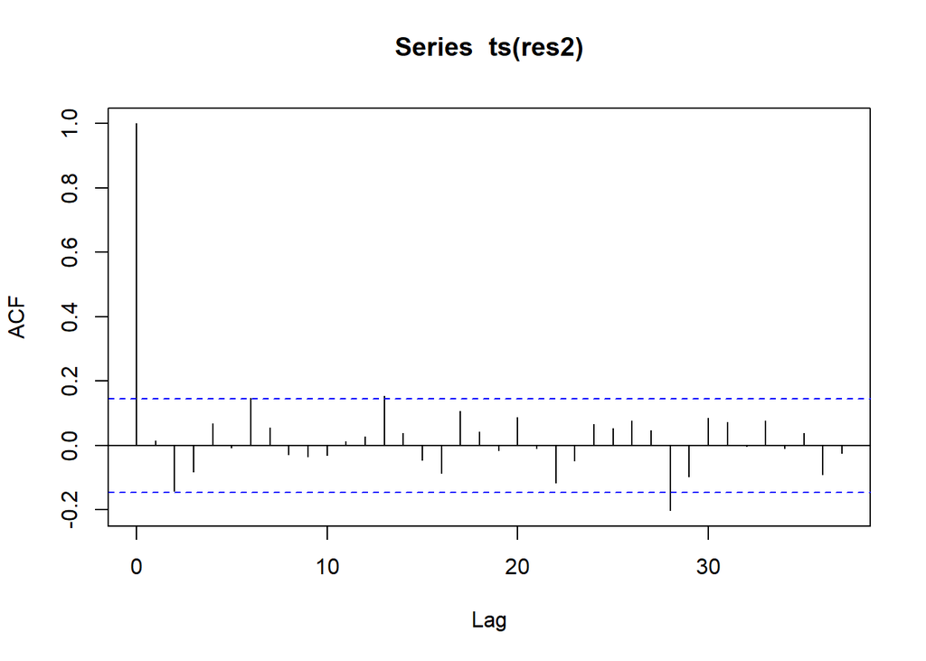

```r
acf(ts(res2), 37)
```

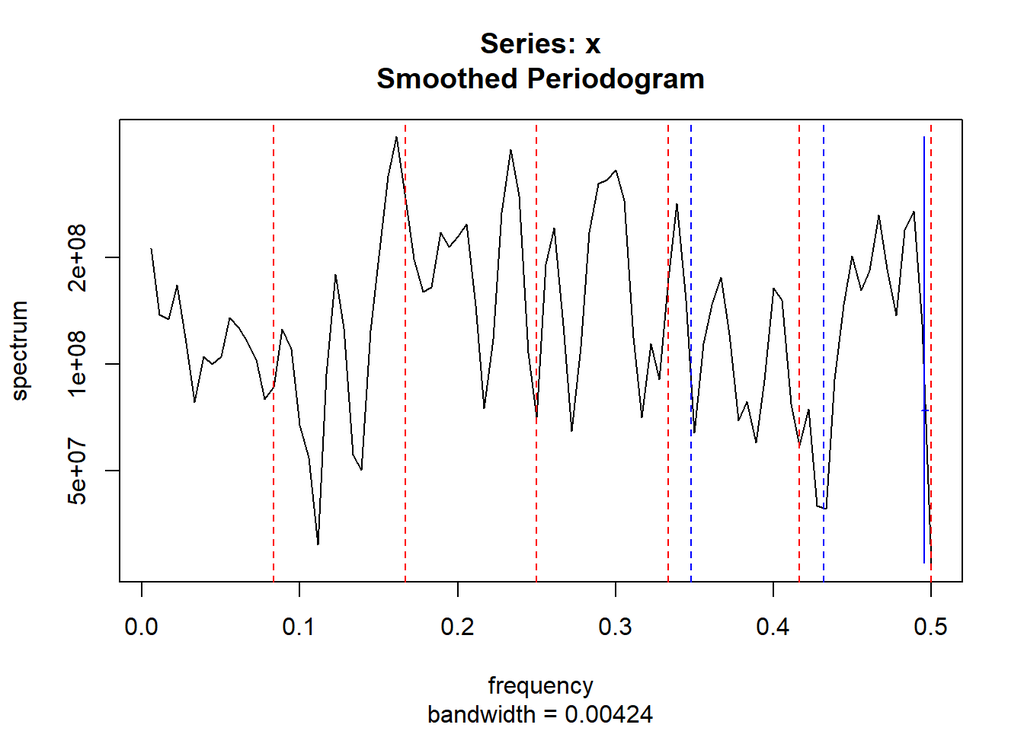

```r
spectrum(res2, span=3)
abline(v=c(1/12,2/12,3/12,4/12,5/12,6/12),col="red",lty=2)
abline(v=c(0.348,0.432),col="blue",lty=2)
```

```r
AIC(model2)
```

```
## [1] 3965.163
```

**Discussion:** This model 3 shows a little bit of improvement in terms of AIC: the AIC IS now 3961.624, down from 3965.16 previously. This is in part due to the reduction of lagged advertising variables (we include in model3 only the first two lagged advertising variables compared to all four lagged advertising variables in the previous model).

```r
model3 <- lm(msales~madv+madvl1+madvl2+msalesl1+msalesl2+msalesl3+fMonth+feb44+dec44+jan45+sep45+c220+s220+c348+s348+c432+s432)

summary(model3)
```

```
##
## Call:
## lm(formula = msales ~ madv + madvl1 + madvl2 + msalesl1 + msalesl2 +
##     msalesl3 + fMonth + feb44 + dec44 + jan45 + sep45 + c220 +
##     s220 + c348 + s348 + c432 + s432)
##
## Residuals:
##    Min     1Q Median     3Q    Max
## -31794  -9214      0   7656  39252
##
## Coefficients:
##               Estimate Std. Error t value Pr(>|t|)
## (Intercept)  2.236e+04  7.641e+03   2.927 0.003954 **
## madv         2.216e-01  4.317e-02   5.133 8.61e-07 ***
## madvl1       9.939e-02  4.799e-02   2.071 0.040045 *
## madvl2      -3.087e-02  4.529e-02  -0.682 0.496544
## msalesl1     4.601e-01  7.133e-02   6.450 1.41e-09 ***
## msalesl2     2.738e-01  7.253e-02   3.775 0.000229 ***
## msalesl3     1.190e-01  6.514e-02   1.827 0.069625 .
## fMonth2     -1.714e+04  8.027e+03  -2.135 0.034351 *
## fMonth3     -6.422e+03  7.918e+03  -0.811 0.418581
## fMonth4     -2.947e+04  7.069e+03  -4.169 5.12e-05 ***
## fMonth5     -2.799e+04  7.039e+03  -3.977 0.000108 ***
## fMonth6     -2.893e+04  5.990e+03  -4.830 3.30e-06 ***
## fMonth7     -1.055e+04  6.012e+03  -1.755 0.081272 .
## fMonth8     -1.129e+04  6.499e+03  -1.737 0.084478 .
## fMonth9     -6.802e+03  7.248e+03  -0.938 0.349534
## fMonth10    -3.104e+03  7.305e+03  -0.425 0.671451
## fMonth11    -4.742e+04  7.956e+03  -5.960 1.69e-08 ***
## fMonth12    -4.952e+04  6.795e+03  -7.288 1.60e-11 ***
## feb44       -4.378e+04  1.512e+04  -2.896 0.004333 **
## dec44       -5.337e+04  1.447e+04  -3.688 0.000314 ***
## jan45        7.568e+04  1.488e+04   5.086 1.06e-06 ***
## sep45       -4.380e+04  1.462e+04  -2.996 0.003192 **
## c220         3.409e+03  1.459e+03   2.337 0.020761 *
## s220         9.791e+02  1.501e+03   0.652 0.515198
## c348         5.389e+02  1.540e+03   0.350 0.726943
## s348        -3.594e+03  1.501e+03  -2.394 0.017868 *
## c432        -1.095e+03  1.479e+03  -0.741 0.460137
## s432         1.371e+02  1.466e+03   0.094 0.925567
## ---
## Signif. codes:  0 '***' 0.001 '**' 0.01 '*' 0.05 '.' 0.1 ' ' 1
##
## Residual standard error: 13480 on 152 degrees of freedom
## Multiple R-squared:  0.8986, Adjusted R-squared:  0.8805
## F-statistic: 49.86 on 27 and 152 DF,  p-value: < 2.2e-16
```

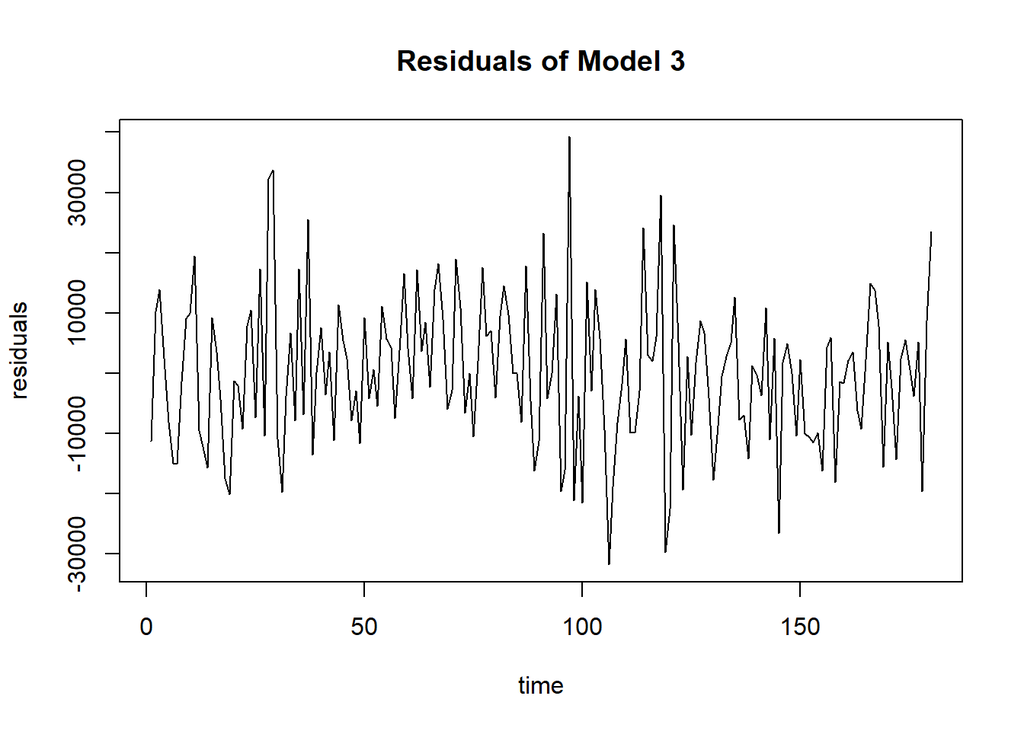

```r
res3 <- resid(model3)
resid3 <- ts(res3) #,start=c(1992,1),freq=12)
plot(resid3, xlab="time",ylab="residuals",main="Residuals of Model 3")
```

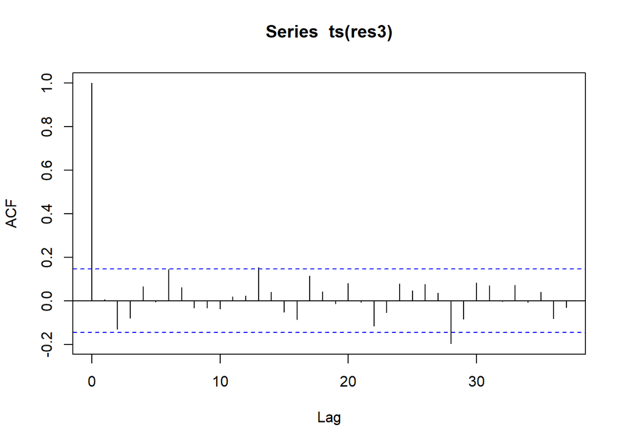

```r
acf(ts(res3), 37)
```

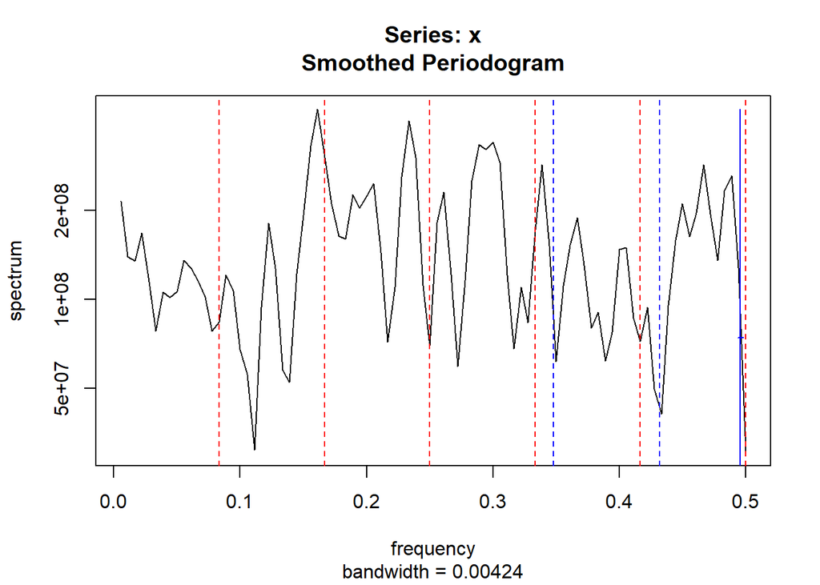

```r
spectrum(res3, span=3)
abline(v=c(1/12,2/12,3/12,4/12,5/12,6/12),col="red",lty=2)
abline(v=c(0.348,0.432),col="blue",lty=2)
```

```r
AIC(model3)
```

```
## [1] 3961.624
```

```r
model3.1 <- lm(msales~madv+msalesl1+msalesl2+msalesl3+fMonth+feb44+dec44+jan45+sep45+c220+s220+c348+s348+c432+s432)

anova(model3.1, model3)
```

```
## Analysis of Variance Table
##
## Model 1: msales ~ madv + msalesl1 + msalesl2 + msalesl3 + fMonth + feb44 +
##     dec44 + jan45 + sep45 + c220 + s220 + c348 + s348 + c432 +
##     s432
## Model 2: msales ~ madv + madvl1 + madvl2 + msalesl1 + msalesl2 + msalesl3 +
##     fMonth + feb44 + dec44 + jan45 + sep45 + c220 + s220 + c348 +
##     s348 + c432 + s432
##   Res.Df        RSS Df Sum of Sq      F Pr(>F)
## 1    154 2.8405e+10
## 2    152 2.7622e+10  2 783058353 2.1545 0.1195
```

**Discussion:** In this model we exclude the variable madvl2 and noticed an improvement in AIC from 3161.62 to 3960.17. The advertising and lagged advertising variables are now shown to be significant. Next we conduct partial f-test to test the significance of fMonth and calendar pair variables.

```r
model4 <- lm(msales~madv+madvl1+msalesl1+msalesl2+msalesl3+fMonth+feb44+dec44+jan45+sep45+c220+s220+c348+s348+c432+s432)

summary(model4)
```

```
##
## Call:
## lm(formula = msales ~ madv + madvl1 + msalesl1 + msalesl2 + msalesl3 +
##     fMonth + feb44 + dec44 + jan45 + sep45 + c220 + s220 + c348 +
##     s348 + c432 + s432)
##
## Residuals:
##    Min     1Q Median     3Q    Max
## -32067  -8886      0   7254  38490
##
## Coefficients:
##               Estimate Std. Error t value Pr(>|t|)
## (Intercept)  2.098e+04  7.353e+03   2.853 0.004933 **
## madv         2.280e-01  4.205e-02   5.424 2.24e-07 ***
## madvl1       9.077e-02  4.621e-02   1.964 0.051321 .
## msalesl1     4.502e-01  6.971e-02   6.458 1.34e-09 ***
## msalesl2     2.673e-01  7.176e-02   3.724 0.000275 ***
## msalesl3     1.249e-01  6.446e-02   1.937 0.054561 .
## fMonth2     -1.489e+04  7.307e+03  -2.038 0.043246 *
## fMonth3     -5.424e+03  7.768e+03  -0.698 0.486029
## fMonth4     -2.849e+04  6.908e+03  -4.124 6.09e-05 ***
## fMonth5     -2.765e+04  7.009e+03  -3.945 0.000121 ***
## fMonth6     -2.877e+04  5.975e+03  -4.815 3.50e-06 ***
## fMonth7     -9.567e+03  5.826e+03  -1.642 0.102597
## fMonth8     -9.900e+03  6.162e+03  -1.607 0.110182
## fMonth9     -5.163e+03  6.826e+03  -0.756 0.450599
## fMonth10    -2.057e+03  7.129e+03  -0.289 0.773323
## fMonth11    -4.656e+04  7.841e+03  -5.938 1.87e-08 ***
## fMonth12    -4.951e+04  6.783e+03  -7.298 1.48e-11 ***
## feb44       -4.368e+04  1.509e+04  -2.895 0.004348 **
## dec44       -5.407e+04  1.441e+04  -3.752 0.000248 ***
## jan45        7.573e+04  1.485e+04   5.099 9.98e-07 ***
## sep45       -4.384e+04  1.459e+04  -3.005 0.003109 **
## c220         3.431e+03  1.456e+03   2.356 0.019736 *
## s220         9.970e+02  1.498e+03   0.665 0.506739
## c348         7.145e+02  1.516e+03   0.471 0.638107
## s348        -3.518e+03  1.494e+03  -2.354 0.019838 *
## c432        -1.002e+03  1.470e+03  -0.681 0.496758
## s432         2.409e+02  1.455e+03   0.166 0.868712
## ---
## Signif. codes:  0 '***' 0.001 '**' 0.01 '*' 0.05 '.' 0.1 ' ' 1
##
## Residual standard error: 13460 on 153 degrees of freedom
## Multiple R-squared:  0.8982, Adjusted R-squared:  0.881
## F-statistic: 51.95 on 26 and 153 DF,  p-value: < 2.2e-16
```

```r
AIC(model4)
```

```
## [1] 3960.173
```

**Partial F-test testing the significance of fMonth variables**

**Discussion:** Partial f-tests below indicate that fMonth variables are significant.

```r
model5.1 <- lm(msales~madv+madvl1+msalesl1+msalesl2+msalesl3+fMonth+feb44+dec44+jan45+sep45+c220+s220+c348+s348+c432+s432)

model5.2 <- lm(msales~madv+madvl1+msalesl1+msalesl2+msalesl3+feb44+dec44+jan45+sep45+c348+c220+s220+s348+c432+s432)

anova(model5.2, model5.1)
```

```
## Analysis of Variance Table
##
## Model 1: msales ~ madv + madvl1 + msalesl1 + msalesl2 + msalesl3 + feb44 +
##     dec44 + jan45 + sep45 + c348 + c220 + s220 + s348 + c432 +
##     s432
## Model 2: msales ~ madv + madvl1 + msalesl1 + msalesl2 + msalesl3 + fMonth +
##     feb44 + dec44 + jan45 + sep45 + c220 + s220 + c348 + s348 +
##     c432 + s432
##   Res.Df        RSS Df  Sum of Sq      F    Pr(>F)
## 1    164 5.1831e+10
## 2    153 2.7706e+10 11 2.4125e+10 12.111 3.567e-16 ***
## ---
## Signif. codes:  0 '***' 0.001 '**' 0.01 '*' 0.05 '.' 0.1 ' ' 1
```

**Partial F-test testing the significance of calendar pair variables**

**Discussion:** Partial f-tests below indicate that calendar pairs 220, 348, and 432 have significances of .05286, 0.05859, and 0.7798 respectively. Based on this we can remove the 432 pair. After removing the pair, the AIC improves to 3956.76 from 3960.17

```r
model5.3 <- lm(msales~madv+madvl1+msalesl1+msalesl2+msalesl3+fMonth+feb44+dec44+jan45+sep45+c348+s348+c432+s432)

anova(model5.3, model5.1)
```

```
## Analysis of Variance Table
##
## Model 1: msales ~ madv + madvl1 + msalesl1 + msalesl2 + msalesl3 + fMonth +
##     feb44 + dec44 + jan45 + sep45 + c348 + s348 + c432 + s432
## Model 2: msales ~ madv + madvl1 + msalesl1 + msalesl2 + msalesl3 + fMonth +
##     feb44 + dec44 + jan45 + sep45 + c220 + s220 + c348 + s348 +
##     c432 + s432
##   Res.Df        RSS Df  Sum of Sq      F  Pr(>F)
## 1    155 2.8792e+10
## 2    153 2.7706e+10  2 1085535089 2.9973 0.05286 .
## ---
## Signif. codes:  0 '***' 0.001 '**' 0.01 '*' 0.05 '.' 0.1 ' ' 1
```

```r
model5.4 <- lm(msales~madv+madvl1+msalesl1+msalesl2+msalesl3+fMonth+feb44+dec44+jan45+sep45+c220+s220+c432+s432)

anova(model5.4, model5.1)
```

```
## Analysis of Variance Table
##
## Model 1: msales ~ madv + madvl1 + msalesl1 + msalesl2 + msalesl3 + fMonth +
##     feb44 + dec44 + jan45 + sep45 + c220 + s220 + c432 + s432
## Model 2: msales ~ madv + madvl1 + msalesl1 + msalesl2 + msalesl3 + fMonth +
##     feb44 + dec44 + jan45 + sep45 + c220 + s220 + c348 + s348 +
##     c432 + s432
##   Res.Df        RSS Df  Sum of Sq      F  Pr(>F)
## 1    155 2.8753e+10
## 2    153 2.7706e+10  2 1046886000 2.8905 0.05859 .
## ---
## Signif. codes:  0 '***' 0.001 '**' 0.01 '*' 0.05 '.' 0.1 ' ' 1
```

```r
model5.5 <- lm(msales~madv+madvl1+msalesl1+msalesl2+msalesl3+fMonth+feb44+dec44+jan45+sep45+c220+s220+c348+s348)

anova(model5.5, model5.1)
```

```
## Analysis of Variance Table
##
## Model 1: msales ~ madv + madvl1 + msalesl1 + msalesl2 + msalesl3 + fMonth +
##     feb44 + dec44 + jan45 + sep45 + c220 + s220 + c348 + s348
## Model 2: msales ~ madv + madvl1 + msalesl1 + msalesl2 + msalesl3 + fMonth +
##     feb44 + dec44 + jan45 + sep45 + c220 + s220 + c348 + s348 +
##     c432 + s432
##   Res.Df        RSS Df Sum of Sq      F Pr(>F)
## 1    155 2.7797e+10
## 2    153 2.7706e+10  2  90227241 0.2491 0.7798
```

```r
model6<- lm(msales~madv+madvl1+msalesl1+msalesl2+msalesl3+fMonth+feb44+dec44+jan45+sep45+c220+s220+c348+s348)

AIC(model6)
```

```
## [1] 3956.758
```

**final model**

The final model includes as variables: - contemporary advertising - lag 1 advertising variables (madvl1) - all the lag sales variables (msalesl1-msalesl3) - the fmonth dummy variables to account for seasonality - all four outlier variables(feb44, dec44, jan45, sep45) - calendar pairs 220 and 348

We conduct a final partial f-test to determine the significance of lagged advertising variables (madvl2, madvl3, madvl4) and the test concludes that they do not Granger-cause msales with p-value of 0.8088.

A look at the seasonal indices plot indicate that, annually and on average, sales drop in April to June and rises from August to October before dropping in November and December. Thereafter sales would pick up in January to March before dropping in April.

```r
model6<- lm(msales~madv+madvl1+msalesl1+msalesl2+msalesl3+fMonth+feb44+dec44+jan45+sep45+c220+s220+c348+s348)

model6.1<- lm(msales~madv+madvl1+madvl2+madvl3+madvl4+msalesl1+msalesl2+msalesl3+fMonth+feb44+dec44+jan45+sep45+c220+s220+c348+s348)

anova(model6.1, model6)
```

```
## Analysis of Variance Table
##
## Model 1: msales ~ madv + madvl1 + madvl2 + madvl3 + madvl4 + msalesl1 +
##     msalesl2 + msalesl3 + fMonth + feb44 + dec44 + jan45 + sep45 +
##     c220 + s220 + c348 + s348
## Model 2: msales ~ madv + madvl1 + msalesl1 + msalesl2 + msalesl3 + fMonth +
##     feb44 + dec44 + jan45 + sep45 + c220 + s220 + c348 + s348
##   Res.Df        RSS Df  Sum of Sq     F Pr(>F)
## 1    152 2.7621e+10
## 2    155 2.7797e+10 -3 -176060182 0.323 0.8088
```

```r
b1<-coef(model6)[1]
b2<-coef(model6)[7:17]+b1
b3<-c(b1,b2)
seas<-b3-mean(b3)

seas.ts<-ts(seas)
seas
```

```
## (Intercept)     fMonth2     fMonth3     fMonth4     fMonth5     fMonth6
##   18954.498    4501.648   13321.164   -9409.932   -8671.434   -9826.754
##     fMonth7     fMonth8     fMonth9    fMonth10    fMonth11    fMonth12
##    9447.281    9113.859   13779.909   16997.011  -27539.025  -30668.224
```

```r
seas.ts
```

```
## Time Series:
## Start = 1
## End = 12
## Frequency = 1
## (Intercept)     fMonth2     fMonth3     fMonth4     fMonth5     fMonth6
##   18954.498    4501.648   13321.164   -9409.932   -8671.434   -9826.754
##     fMonth7     fMonth8     fMonth9    fMonth10    fMonth11    fMonth12
##    9447.281    9113.859   13779.909   16997.011  -27539.025  -30668.224
```

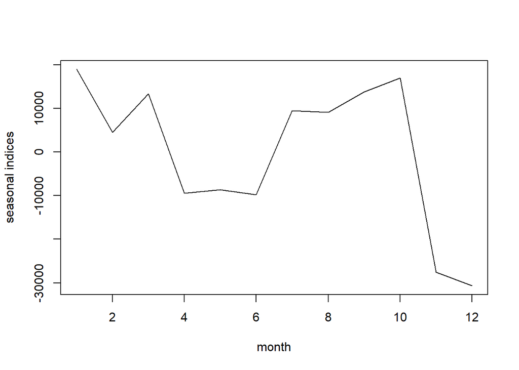

```r
plot(seas.ts,ylab="seasonal indices",xlab="month")
```

## Problem 1.b.1

Analyze the residuals from your model. Give a normal quantile plot, plot the residuals vs. time, present the residual autocorrelations and partial autocorrelations, and produce the residual spectral density plot. Discuss the results carefully.

**Discussion:** The qqplot indicates that normality has been roughly achieved, as most observations fall on the qqline. There are a few deviations at the tails, however they are a few compared to the the vast majority of observations which fall on the line.

The residuals plot show that it is largely flat and variance is relatively constant around the mean of 0. We cannot reject that homoscedacticity is not achieved based on this plot.

The ACF and PACF plots show no significant autocorrelation except for lag 28 in the ACF plot. There are a few lags in the two plots which seem to reach the blue line but they do not excessively cross the line. I decided to leave them as is as they do not constitute a major issue for the model.

The residual spectral density plot indicates that white noise reduction has been achieved as the distance between highest and lowest peaks of the plot is less than twice the length of the blue measurement line above the notch.

```r
res6 <- resid(model6)
```

**normal quantile plot**

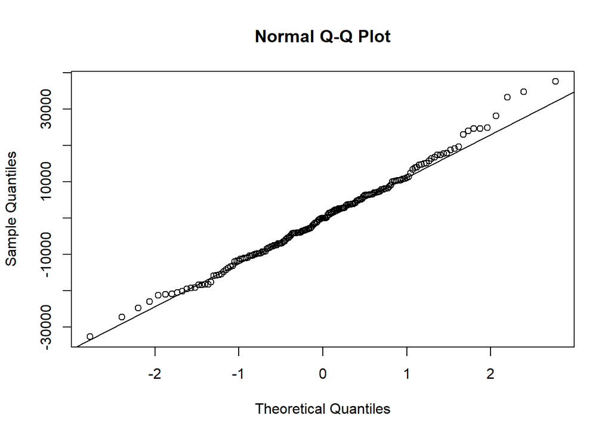

```r
qqnorm(res6)
qqline(res6)
```

**plot the residuals vs. time**

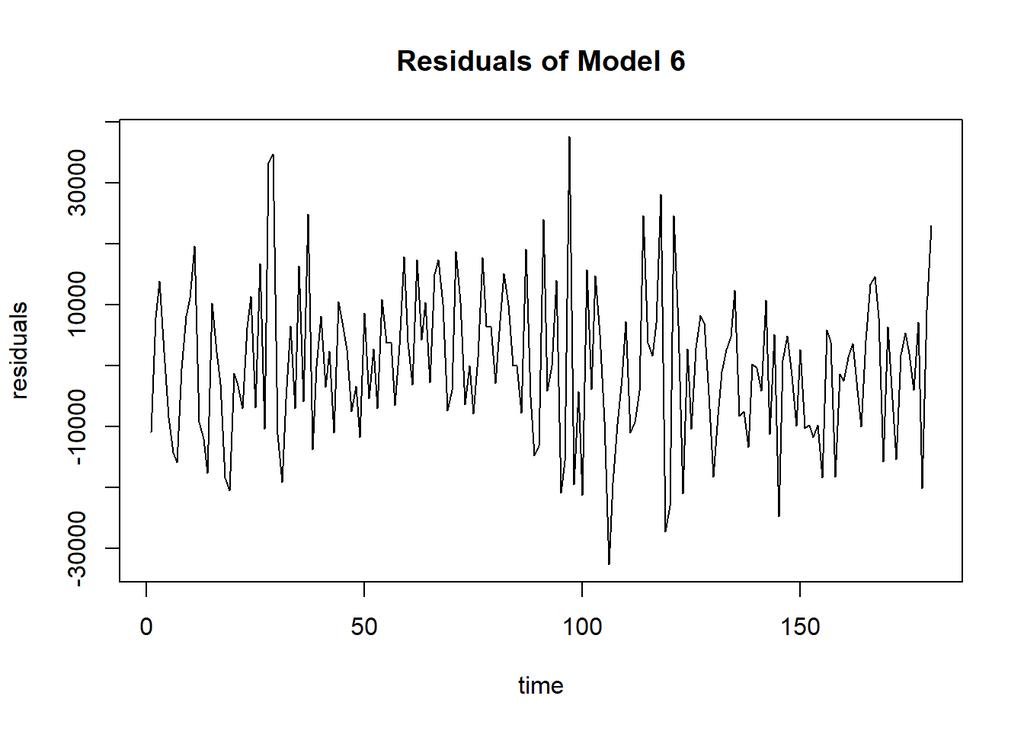

```r
plot(ts(res6), xlab="time",ylab="residuals",main="Residuals of Model 6")
```

**present the residual autocorrelations and partial autocorrelations**

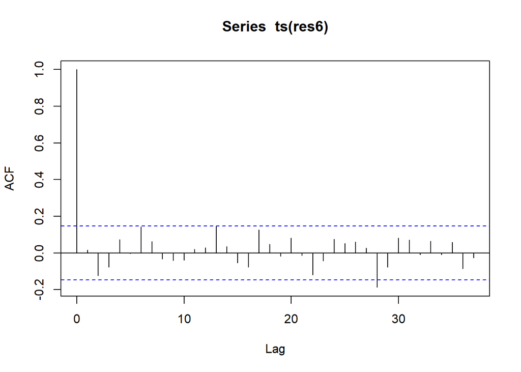

```r
acf(ts(res6), 37)
```

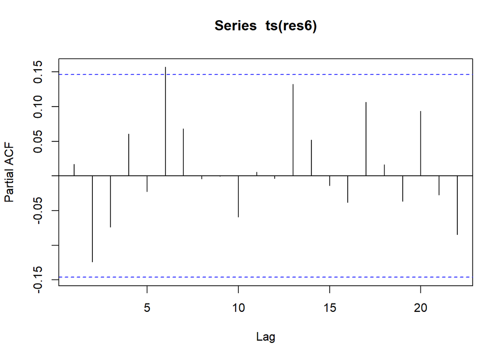

```r
pacf(ts(res6))
```

**produce the residual spectral density plot**

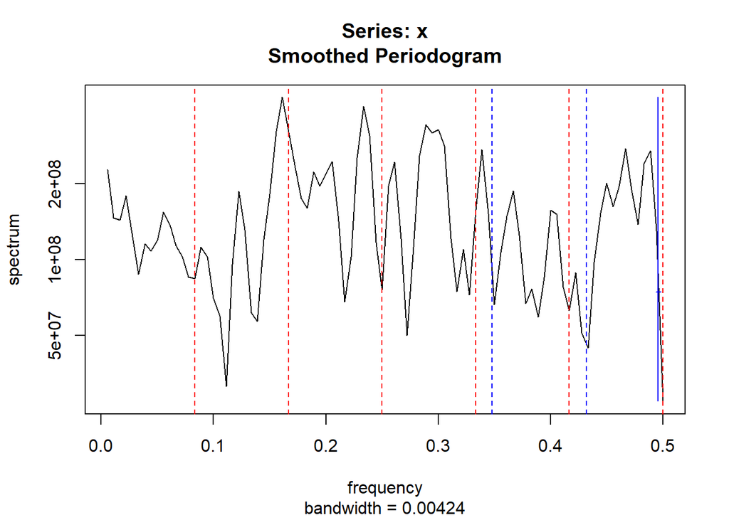

```r
spectrum(res6, span=3)
abline(v=c(1/12,2/12,3/12,4/12,5/12,6/12),col="red",lty=2)
abline(v=c(0.348,0.432),col="blue",lty=2)
```

```r
summary(model6)
```

```
##
## Call:
## lm(formula = msales ~ madv + madvl1 + msalesl1 + msalesl2 + msalesl3 +
##     fMonth + feb44 + dec44 + jan45 + sep45 + c220 + s220 + c348 +
##     s348)
##
## Residuals:
##    Min     1Q Median     3Q    Max
## -32653  -8676      0   7311  37616
##
## Coefficients:
##               Estimate Std. Error t value Pr(>|t|)
## (Intercept)  2.092e+04  7.311e+03   2.861 0.004806 **
## madv         2.296e-01  4.142e-02   5.544 1.24e-07 ***
## madvl1       8.894e-02  4.558e-02   1.951 0.052830 .
## msalesl1     4.458e-01  6.910e-02   6.452 1.34e-09 ***
## msalesl2     2.766e-01  7.006e-02   3.948 0.000119 ***
## msalesl3     1.202e-01  6.374e-02   1.885 0.061245 .
## fMonth2     -1.445e+04  7.243e+03  -1.996 0.047740 *
## fMonth3     -5.633e+03  7.724e+03  -0.729 0.466896
## fMonth4     -2.836e+04  6.869e+03  -4.129 5.93e-05 ***
## fMonth5     -2.763e+04  6.970e+03  -3.963 0.000113 ***
## fMonth6     -2.878e+04  5.938e+03  -4.847 3.02e-06 ***
## fMonth7     -9.507e+03  5.796e+03  -1.640 0.102996
## fMonth8     -9.841e+03  6.129e+03  -1.606 0.110408
## fMonth9     -5.175e+03  6.792e+03  -0.762 0.447329
## fMonth10    -1.957e+03  7.091e+03  -0.276 0.782882
## fMonth11    -4.649e+04  7.796e+03  -5.964 1.61e-08 ***
## fMonth12    -4.962e+04  6.736e+03  -7.367 9.73e-12 ***
## feb44       -4.508e+04  1.488e+04  -3.030 0.002869 **
## dec44       -5.374e+04  1.425e+04  -3.771 0.000230 ***
## jan45        7.543e+04  1.471e+04   5.129 8.59e-07 ***
## sep45       -4.439e+04  1.439e+04  -3.086 0.002405 **
## c220         3.460e+03  1.448e+03   2.389 0.018105 *
## s220         1.014e+03  1.490e+03   0.680 0.497375
## c348         7.749e+02  1.505e+03   0.515 0.607476
## s348        -3.511e+03  1.486e+03  -2.363 0.019381 *
## ---
## Signif. codes:  0 '***' 0.001 '**' 0.01 '*' 0.05 '.' 0.1 ' ' 1
##
## Residual standard error: 13390 on 155 degrees of freedom
## Multiple R-squared:  0.8979, Adjusted R-squared:  0.8821
## F-statistic:  56.8 on 24 and 155 DF,  p-value: < 2.2e-16
```

## Problem 1.c

Calculate the estimate of the 90 per cent duration interval and discuss the result.

```r
summary(model6)
```

```
##
## Call:
## lm(formula = msales ~ madv + madvl1 + msalesl1 + msalesl2 + msalesl3 +
##     fMonth + feb44 + dec44 + jan45 + sep45 + c220 + s220 + c348 +
##     s348)
##
## Residuals:
##    Min     1Q Median     3Q    Max
## -32653  -8676      0   7311  37616
##
## Coefficients:
##               Estimate Std. Error t value Pr(>|t|)
## (Intercept)  2.092e+04  7.311e+03   2.861 0.004806 **
## madv         2.296e-01  4.142e-02   5.544 1.24e-07 ***
## madvl1       8.894e-02  4.558e-02   1.951 0.052830 .
## msalesl1     4.458e-01  6.910e-02   6.452 1.34e-09 ***
## msalesl2     2.766e-01  7.006e-02   3.948 0.000119 ***
## msalesl3     1.202e-01  6.374e-02   1.885 0.061245 .
## fMonth2     -1.445e+04  7.243e+03  -1.996 0.047740 *
## fMonth3     -5.633e+03  7.724e+03  -0.729 0.466896
## fMonth4     -2.836e+04  6.869e+03  -4.129 5.93e-05 ***
## fMonth5     -2.763e+04  6.970e+03  -3.963 0.000113 ***
## fMonth6     -2.878e+04  5.938e+03  -4.847 3.02e-06 ***
## fMonth7     -9.507e+03  5.796e+03  -1.640 0.102996
## fMonth8     -9.841e+03  6.129e+03  -1.606 0.110408
## fMonth9     -5.175e+03  6.792e+03  -0.762 0.447329
## fMonth10    -1.957e+03  7.091e+03  -0.276 0.782882
## fMonth11    -4.649e+04  7.796e+03  -5.964 1.61e-08 ***
## fMonth12    -4.962e+04  6.736e+03  -7.367 9.73e-12 ***
## feb44       -4.508e+04  1.488e+04  -3.030 0.002869 **
## dec44       -5.374e+04  1.425e+04  -3.771 0.000230 ***
## jan45        7.543e+04  1.471e+04   5.129 8.59e-07 ***
## sep45       -4.439e+04  1.439e+04  -3.086 0.002405 **
## c220         3.460e+03  1.448e+03   2.389 0.018105 *
## s220         1.014e+03  1.490e+03   0.680 0.497375
## c348         7.749e+02  1.505e+03   0.515 0.607476
## s348        -3.511e+03  1.486e+03  -2.363 0.019381 *
## ---
## Signif. codes:  0 '***' 0.001 '**' 0.01 '*' 0.05 '.' 0.1 ' ' 1
##
## Residual standard error: 13390 on 155 degrees of freedom
## Multiple R-squared:  0.8979, Adjusted R-squared:  0.8821
## F-statistic:  56.8 on 24 and 155 DF,  p-value: < 2.2e-16
```

St = 20920 + 0.4458St-1 + 0.2766St-2 + 0.1202St-3 + 0.2296At + .08894At-1 + …

(1 – 0.4458BSt-1 - 0.2766B^2St-2 - 0.1202B^3St-3) St = 20920 + 0.2296At + .08894At-1 + …

We have a case where p = 3, r = 1, so p >= r,

Now we calculate deltas

delta0 = .2296 delta1 = .08894 + (0.4458 * .2296) = .1913

```r
deltapartial<-delta<-c(rep(0,times=500))
#deltapartial is the partial sum of the deltas
delta[1]<-0.2296
delta[2]<-0.1913

deltapartial[1]<-delta[1]
deltapartial[2]<-deltapartial[1]+delta[2]
for(j in 3:500){
j1<-j-1;j2<-j-2
delta[j]<-0.4458*delta[j1]+0.2766*delta[j2]
deltapartial[j]<-deltapartial[j1]+delta[j]
}

deltapartial[500]*0.9
```

```
## [1] 1.032745
```

```r
deltapartial[1:20]
```

```
##  [1] 0.2296000 0.4209000 0.5696889 0.6889326 0.7832464 0.8582743 0.9178090
##  [8] 0.9651022 1.0026529 1.0324742 1.0561551 1.0749606 1.0898943 1.1017533
## [15] 1.1111707 1.1186492 1.1245879 1.1293040 1.1330491 1.1360231
```

# Problem 2

The file qconsumption2.txt contains quarterly data measuring U.S. Real Personal Consumption Expenditures percentage changes for the period 1953.1 to 2019.4. The data are seasonally adjusted.

```r
consumption <- read.csv("qconsumption2.txt")
attach(consumption)
```

1. Work with the data spanning the period 1953.1 to 2007.4.
2. Plot the data vs. time and discuss features of the plot. Give a list of the economic downturns as determined by the Business Cycle Dating Committee of NBER. Can you relate these recessions to movements in the plot?

**Discussion:** Personal consumption expenditures percentage changes drop during recessions. Recession periods are highlighted in orange below and as we can see, percent changes consistently drops during recession periods.

Personal consumption expenditures percentage changes are mostly positive from 1953 to 2007, the only exception being negative percentage changes during most of the highlighted recession periods. This indicates that recession largely drives consumers to reduce their personal consumption expenditures.

```r
# we manually input the contraction periods from NBER.
cycle <- data.frame(from = c('1945-01-01','1948-10-01','1953-07-01','1957-07-01','1960-04-01','1970-01-01','1973-10-01','1980-01-01','1981-07-01','1990-07-01','2001-04-01','2008-01-01','2020-03-01'),
                    to = c('1945-10-01','1949-10-01','1954-04-01','1958-04-01','1961-01-01','1970-10-01','1975-04-01','1980-07-01','1982-10-01','1991-04-01','2001-10-01','2009-07-01','2020-04-01'))
```

```r
# we create a new column "rects" which signals 1 if it row corresponds to a "recession" period according to NEBR data

lst <- rep(0, nrow(consumption))
consumption$rects <-lst

consumption<-transform(consumption,rects=ifelse(Quarter %in% cycle$from,1,rects))
consumption<-transform(consumption,rects=ifelse(Quarter %in% cycle$to,2,rects))

for (i in seq(2, nrow(consumption), by=1)) {
  if (consumption$rects[i] == 0) {
    if (consumption$rects[i-1] == 1) {
       consumption$rects[i] <- 1
    }
  }
}

consumption<-transform(consumption,rects=ifelse(rects==2,1,rects))
```

```r
consumption <- consumption %>% mutate(Time = 1:n())
```

```r
# take the span of 1953.1 to 2007.4
consumption.a <- consumption %>% slice(1:220)
```

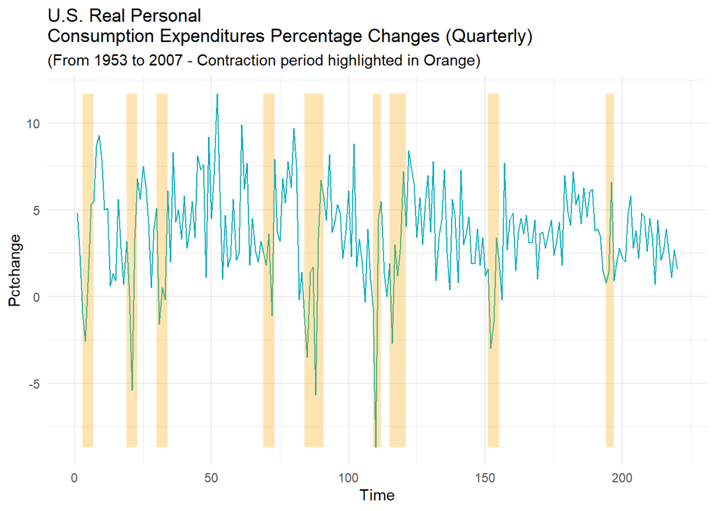

```r
set.seed(0)
dat <- consumption.a

## Determine highlighted regions
v <- dat$rects

## Get the start and end points for highlighted regions
inds <- diff(c(0, v))
#print(v)
start <- dat$Time[inds == 1]
end <- dat$Time[inds == -1]
if (length(start) > length(end)) end <- c(end, tail(dat$Time, 1))

## highlight region data
rects <- data.frame(start=start, end=end, group=seq_along(start))

ggplot(data=dat, aes(Time, Pctchange)) +
theme_minimal() +
geom_line(color = "#00AFBB", size = .5) +
geom_rect(data=rects, inherit.aes=FALSE, aes(xmin=start, xmax=end, ymin=min(dat$Pctchange),
ymax=max(dat$Pctchange), group=group), color="transparent", fill="orange",
alpha=0.3) +
labs(title = "U.S. Real Personal
Consumption Expenditures Percentage Changes (Quarterly)", subtitle = "(From 1953 to 2007 - Contraction period highlighted in Orange)")
```

2. Begin by identifying outliers and form dummies for them. [Form the dummies to have length 220, so they cover the time span from 1953.1 to 2007.4.]

```r
jan58<-rep(0, nrow(consumption.a))
oct65<-rep(0, nrow(consumption.a))
oct74<-rep(0, nrow(consumption.a))
apr80<-rep(0, nrow(consumption.a))

jan58[21] <- 1
oct65[52] <- 1
oct74[88] <- 1
apr80[110] <- 1

consumption.a$jan58 <- jan58
consumption.a$oct65 <- oct65
consumption.a$oct74 <- oct74
consumption.a$apr80 <- apr80
```

3. An ARX model has the form. Then R commands to fit such a model to the percentage changes, if the chosen order of the AR structure is p, are as follows:

df<-data.frame(d1,d2) arxmodel<-arima(Pctchange.ts[1:220],order=c(p,0,0),xreg=df)

Fit an ARX model to the data covering the period 1953.1 to 2007.4. Explain how you arrived at your model fit.

**Discussion:** The initial ACF suggests MA(3) and PACF suggests AR(2) are good places to start.

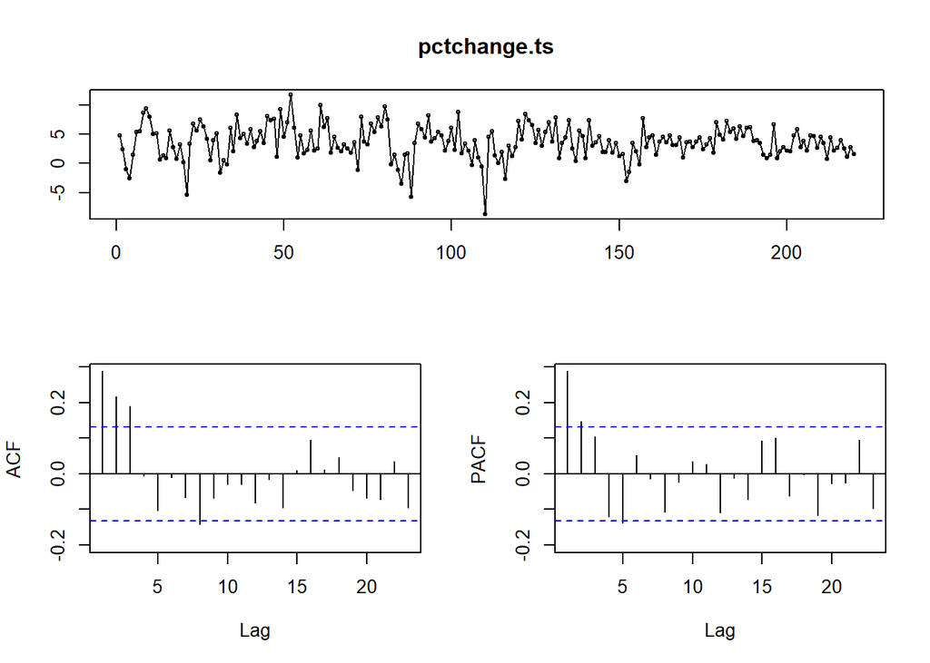

```r
pctchange.ts<-ts(consumption.a$Pctchange)
forecast::tsdisplay(pctchange.ts)
```

We next try an ARMA(2,3), and MA(4) and AR(3) for comparison.

```r
outliers<- consumption.a %>% select(jan58, oct65,oct74,apr80)
outliers<- as.matrix(outliers)
MA3<-Arima(pctchange.ts,order=c(0,0,3), xreg=outliers)
AR2<-Arima(pctchange.ts,order=c(2,0,0), xreg=outliers)
```

MA(3) analysis

```r
summary(MA3)
```

```
## Series: pctchange.ts
## Regression with ARIMA(0,0,3) errors
##
## Coefficients:
##          ma1     ma2     ma3  intercept    jan58   oct65    oct74     apr80
##       0.1876  0.3569  0.2632     3.7032  -7.8517  6.4354  -9.1051  -12.7053
## s.e.  0.0665  0.0652  0.0667     0.2802   2.1540  2.1435   2.0978    2.1089
##
## sigma^2 = 5.507:  log likelihood = -495.98
## AIC=1009.97   AICc=1010.83   BIC=1040.51
##
## Training set error measures:
##                        ME     RMSE      MAE  MPE MAPE      MASE         ACF1
## Training set -0.007702607 2.303681 1.820543 -Inf  Inf 0.6780595 0.0006599653
```

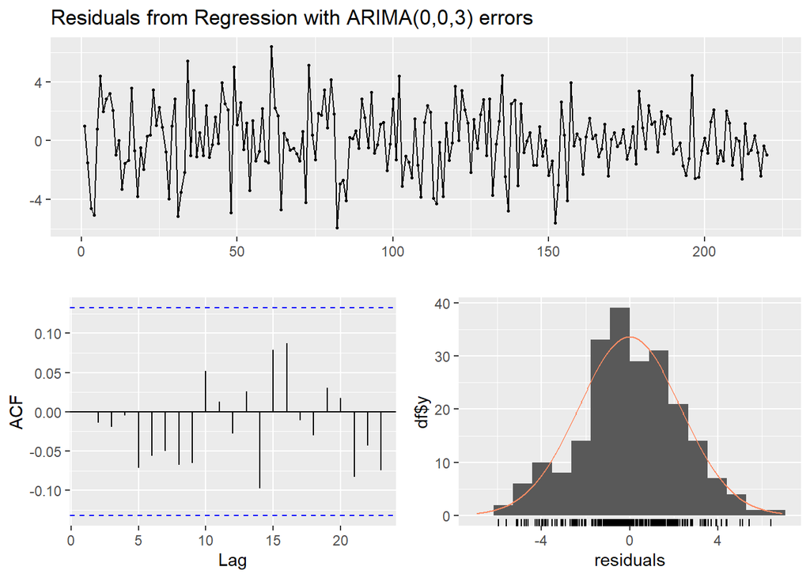

```
##
##  Ljung-Box test
##
## data:  Residuals from Regression with ARIMA(0,0,3) errors
## Q* = 5.3177, df = 3, p-value = 0.15
##
## Model df: 8.   Total lags used: 11
```

```r
checkresiduals(MA3)
```

```r
coeftest(MA3)
```

```
##
## z test of coefficients:
##
##             Estimate Std. Error z value  Pr(>|z|)
## ma1         0.187575   0.066508  2.8204 0.0047971 **
## ma2         0.356894   0.065172  5.4762 4.345e-08 ***
## ma3         0.263220   0.066707  3.9459 7.949e-05 ***
## intercept   3.703234   0.280235 13.2147 < 2.2e-16 ***
## jan58      -7.851720   2.154031 -3.6451 0.0002673 ***
## oct65       6.435412   2.143473  3.0023 0.0026792 **
## oct74      -9.105138   2.097773 -4.3404 1.422e-05 ***
## apr80     -12.705262   2.108946 -6.0245 1.697e-09 ***
## ---
## Signif. codes:  0 '***' 0.001 '**' 0.01 '*' 0.05 '.' 0.1 ' ' 1
```

AR2 analysis

```r
summary(AR2)
```

```
## Series: pctchange.ts
## Regression with ARIMA(2,0,0) errors
##
## Coefficients:
##          ar1     ar2  intercept    jan58   oct65    oct74     apr80
##       0.2007  0.2473     3.6854  -9.1316  7.6634  -9.2379  -11.7142
## s.e.  0.0663  0.0661     0.2878   2.2747  2.2810   2.2580    2.2582
##
## sigma^2 = 5.77:  log likelihood = -501.51
## AIC=1019.01   AICc=1019.69   BIC=1046.16
##
## Training set error measures:
##                        ME    RMSE      MAE  MPE MAPE      MASE         ACF1
## Training set -0.001426658 2.36358 1.878447 -Inf  Inf 0.6996258 -0.004950909
```

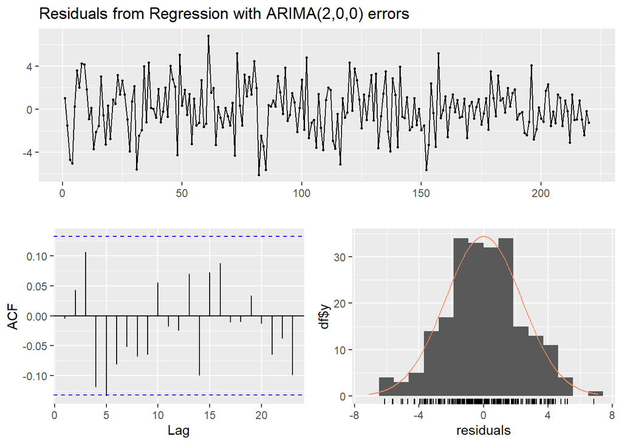

```
##
##  Ljung-Box test
##
## data:  Residuals from Regression with ARIMA(2,0,0) errors
## Q* = 15.174, df = 3, p-value = 0.001674
##
## Model df: 7.   Total lags used: 10
```

```r
checkresiduals(AR2)
```

```r
coeftest(AR2)
```

```
##
## z test of coefficients:
##
##             Estimate Std. Error z value  Pr(>|z|)
## ar1         0.200700   0.066329  3.0258 0.0024797 **
## ar2         0.247291   0.066076  3.7426 0.0001822 ***
## intercept   3.685352   0.287767 12.8067 < 2.2e-16 ***
## jan58      -9.131588   2.274745 -4.0143 5.961e-05 ***
## oct65       7.663437   2.280988  3.3597 0.0007803 ***
## oct74      -9.237895   2.257953 -4.0913 4.290e-05 ***
## apr80     -11.714199   2.258159 -5.1875 2.131e-07 ***
## ---
## Signif. codes:  0 '***' 0.001 '**' 0.01 '*' 0.05 '.' 0.1 ' ' 1
```

**Discussion:** MA(3) still is the best fit with the smallest AIC of 1009.97 after fitting ARMA(2,3), MA(4), and AR(3), with AICs of 1011.2, 1011.96, 1020.87 respectively. We see also in MA(4) and AR(3) that the added lags in each model are insignificant and thus overfit. We can now confidently use MA(3).

```r
ARMA23<-Arima(pctchange.ts,order=c(2,0,3), xreg=outliers)
MA4<-Arima(pctchange.ts,order=c(0,0,4), xreg=outliers)
AR3<-Arima(pctchange.ts,order=c(3,0,0), xreg=outliers)
```

```r
summary(ARMA23)
```

```
## Series: pctchange.ts
## Regression with ARIMA(2,0,3) errors
##
## Coefficients:
##          ar1      ar2      ma1     ma2      ma3  intercept    jan58   oct65
##       1.4260  -0.6255  -1.2778  0.7666  -0.2481     3.7251  -8.9727  7.8307
## s.e.  0.1435   0.1158   0.1539  0.1178   0.0968     0.1884   2.1414  2.1446
##         oct74     apr80
##       -9.2791  -13.0882
## s.e.   2.1468    2.1599
##
## sigma^2 = 5.489:  log likelihood = -494.6
## AIC=1011.2   AICc=1012.47   BIC=1048.53
##
## Training set error measures:
##                       ME     RMSE      MAE  MPE MAPE      MASE       ACF1
## Training set -0.01314106 2.288967 1.840667 -Inf  Inf 0.6855546 0.00813564
```

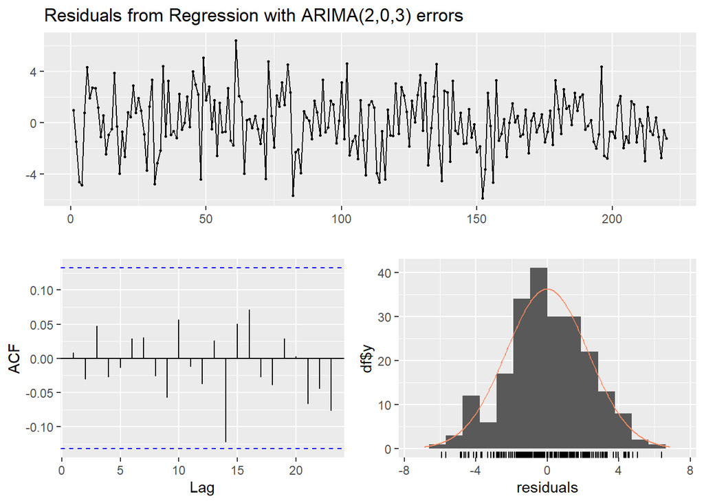

```
##
##  Ljung-Box test
##
## data:  Residuals from Regression with ARIMA(2,0,3) errors
## Q* = 3.5635, df = 3, p-value = 0.3126
##
## Model df: 10.   Total lags used: 13
```

```r
checkresiduals(ARMA23)
```

```r
coeftest(ARMA23)
```

```
##
## z test of coefficients:
##
##             Estimate Std. Error z value  Pr(>|z|)
## ar1         1.425975   0.143539  9.9344 < 2.2e-16 ***
## ar2        -0.625527   0.115842 -5.3998 6.670e-08 ***
## ma1        -1.277779   0.153906 -8.3023 < 2.2e-16 ***
## ma2         0.766639   0.117809  6.5075 7.641e-11 ***
## ma3        -0.248118   0.096786 -2.5636 0.0103601 *
## intercept   3.725072   0.188367 19.7756 < 2.2e-16 ***
## jan58      -8.972699   2.141407 -4.1901 2.788e-05 ***
## oct65       7.830662   2.144578  3.6514 0.0002608 ***
## oct74      -9.279090   2.146781 -4.3223 1.544e-05 ***
## apr80     -13.088195   2.159946 -6.0595 1.365e-09 ***
## ---
## Signif. codes:  0 '***' 0.001 '**' 0.01 '*' 0.05 '.' 0.1 ' ' 1
```

```r
summary(MA4)
```

```
## Series: pctchange.ts
## Regression with ARIMA(0,0,4) errors
##
## Coefficients:
##          ma1     ma2     ma3     ma4  intercept    jan58   oct65    oct74
##       0.1892  0.3585  0.2638  0.0066     3.7030  -7.8770  6.4889  -9.1071
## s.e.  0.0695  0.0682  0.0671  0.0778     0.2818   2.1753  2.2353   2.0991
##          apr80
##       -12.6942
## s.e.    2.1144
##
## sigma^2 = 5.533:  log likelihood = -495.98
## AIC=1011.96   AICc=1013.01   BIC=1045.9
##
## Training set error measures:
##                        ME     RMSE      MAE  MPE MAPE      MASE         ACF1
## Training set -0.007714926 2.303654 1.821641 -Inf  Inf 0.6784683 -0.000930194
```

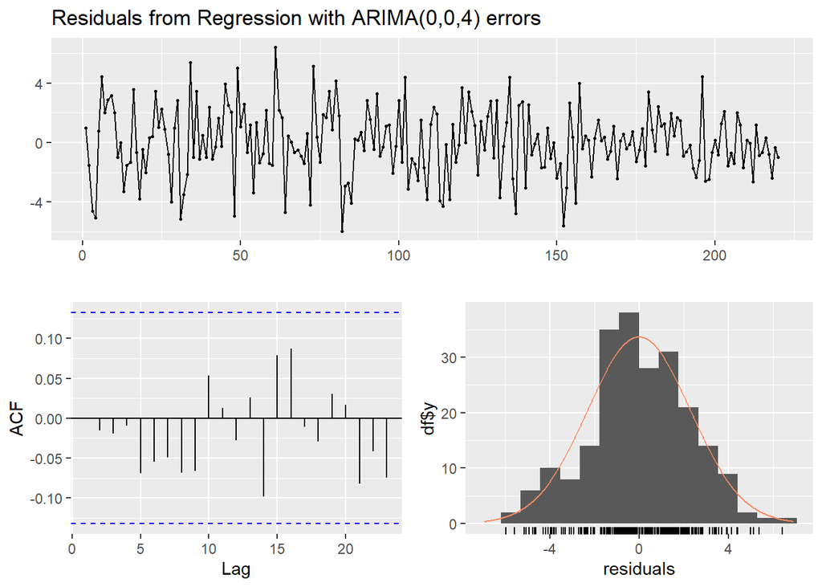

```
##
##  Ljung-Box test
##
## data:  Residuals from Regression with ARIMA(0,0,4) errors
## Q* = 5.4602, df = 3, p-value = 0.141
##
## Model df: 9.   Total lags used: 12
```

```r
checkresiduals(MA4)
```

```r
coeftest(MA4)
```

```
##
## z test of coefficients:
##
##              Estimate  Std. Error z value  Pr(>|z|)
## ma1         0.1892463   0.0695096  2.7226 0.0064772 **
## ma2         0.3585037   0.0681844  5.2579 1.457e-07 ***
## ma3         0.2637990   0.0671061  3.9311 8.457e-05 ***
## ma4         0.0065876   0.0777649  0.0847 0.9324909
## intercept   3.7030197   0.2818404 13.1387 < 2.2e-16 ***
## jan58      -7.8769700   2.1752851 -3.6211 0.0002933 ***
## oct65       6.4889154   2.2353366  2.9029 0.0036975 **
## oct74      -9.1070637   2.0990626 -4.3386 1.434e-05 ***
## apr80     -12.6942495   2.1143766 -6.0038 1.928e-09 ***
## ---
## Signif. codes:  0 '***' 0.001 '**' 0.01 '*' 0.05 '.' 0.1 ' ' 1
```

```r
summary(AR3)
```

```
## Series: pctchange.ts
## Regression with ARIMA(3,0,0) errors
##
## Coefficients:
##          ar1     ar2     ar3  intercept    jan58   oct65    oct74     apr80
##       0.1948  0.2415  0.0264     3.6827  -9.1138  7.5358  -9.1271  -11.6976
## s.e.  0.0682  0.0679  0.0691     0.2954   2.2804  2.3108   2.2806    2.2625
##
## sigma^2 = 5.793:  log likelihood = -501.43
## AIC=1020.87   AICc=1021.72   BIC=1051.41
##
## Training set error measures:
##                         ME     RMSE      MAE  MPE MAPE      MASE        ACF1
## Training set -0.0006923789 2.362787 1.872081 -Inf  Inf 0.6972548 0.006459887
```

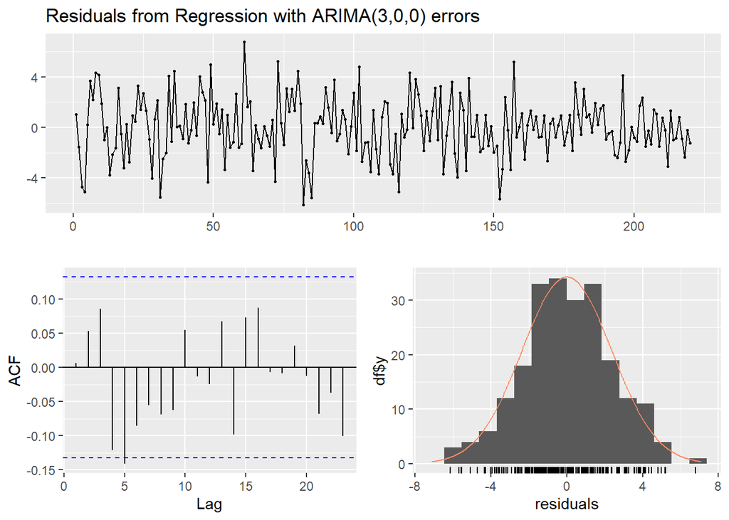

```
##
##  Ljung-Box test
##
## data:  Residuals from Regression with ARIMA(3,0,0) errors
## Q* = 15.238, df = 3, p-value = 0.001624
##
## Model df: 8.   Total lags used: 11
```

```r
checkresiduals(AR3)
```

```r
coeftest(AR3)
```

```
##
## z test of coefficients:
##
##             Estimate Std. Error z value  Pr(>|z|)
## ar1         0.194779   0.068158  2.8578 0.0042664 **
## ar2         0.241465   0.067895  3.5565 0.0003759 ***
## ar3         0.026392   0.069138  0.3817 0.7026593
## intercept   3.682668   0.295351 12.4688 < 2.2e-16 ***
## jan58      -9.113808   2.280396 -3.9966 6.426e-05 ***
## oct65       7.535807   2.310842  3.2611 0.0011099 **
## oct74      -9.127150   2.280609 -4.0021 6.279e-05 ***
## apr80     -11.697557   2.262474 -5.1703 2.338e-07 ***
## ---
## Signif. codes:  0 '***' 0.001 '**' 0.01 '*' 0.05 '.' 0.1 ' ' 1
```

4. Examine the residuals to investigate whether your selected model has achieved reduction to white noise. For this purpose include in your discussion consideration of the residual autocorrelations and partial autocorrelations and the residual spectral density. Also examine and discuss the plot of the residuals vs. time. Perform Bartlett’s test to determine if the fit has produced reduction to white noise. [Bartlett’s test is described and its use is illustrated in the 28 March notes.]

The residuals show constant variance over time, and there is no significant autocorrelation structure that can be seen in the residuals.

Bartlett’s test shows that the model has been reduced to white noise. With a p-value of 0.9949, we cannot reject the null hypothesis that MA(3) fit has been reduced to white noise.

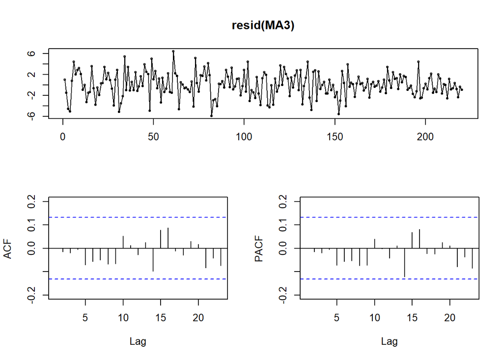

```r
forecast::tsdisplay(resid(MA3))
```

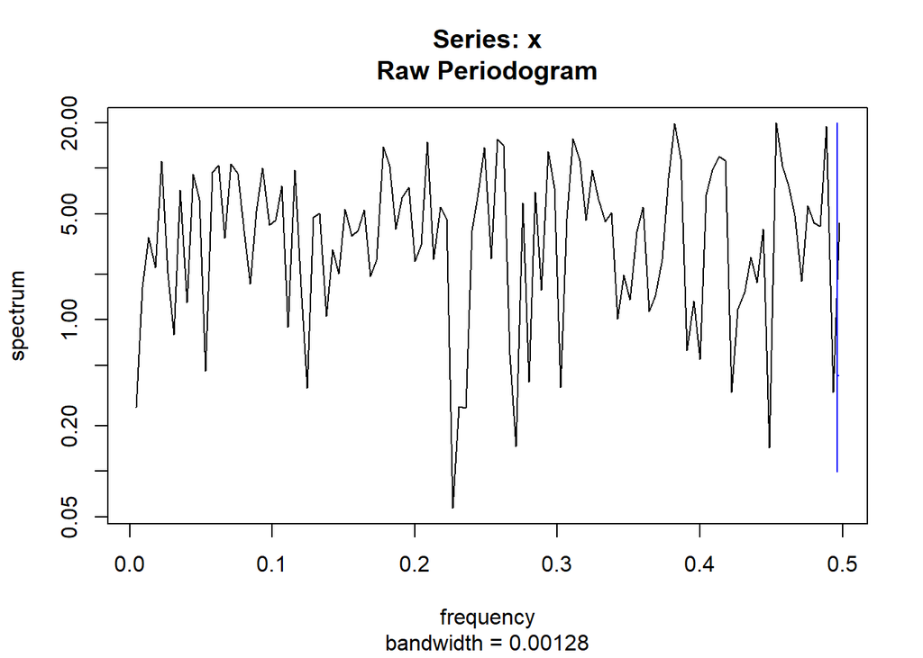

```r
spectrum(resid(MA3))
```

```r
bartlettB.test(ts(resid(MA3)))
```

```
##
##  Bartlett B Test for white noise
##
## data:
## = 0.41767, p-value = 0.9949
```

22. Find the zeros of the autoregressive polynomial for your model fit and interpret the results.

**Discussion:** Since we chose an MA(3) model we find first the autoregressive form of the model by calculating deltas. The amplitude of complex zeros is 0.4477, which suggests that the presence of cycle is weak as it is closer to 0 than 1. The zeros of the autoregressive polynomial suggests the presence of a weak cycle of length about 15.45 quarters. This corresponds to peaks in the estimated spectral density at approximately 1/15.45 = 0.0647 cycles per quarter.

```r
coef(MA3)
```

```
##         ma1         ma2         ma3   intercept       jan58       oct65
##   0.1875751   0.3568942   0.2632198   3.7032337  -7.8517204   6.4354120
##       oct74       apr80
##  -9.1051376 -12.7052624
```

```r
delta<-c(rep(0,times=10))
delta[1]<-1
delta[2]<--0.1875751

for(j in 3:10){
j1<-j-1
j2<-j-2
delta[j]<-- 0.1875751*delta[j1]-0.3568942*delta[j2]
}

delta
```

```
##  [1]  1.000000000 -0.187575100 -0.321709782  0.127289210  0.090940069
##  [6] -0.062486873 -0.020735002  0.026190573  0.002487503 -0.009813857
```

```r
# choosing delta[1:4] because MA(3) model has 3 coefficients
zeros<-1/polyroot(delta[1:4])
zeros
```

```
## [1]  0.4112396-0.1771092i -0.6349042+0.0000000i  0.4112396+0.1771092i
```

```r
#amplitude. Selecting zero with positive imaginary part.
Mod(zeros[3])
```

```
## [1] 0.4477563
```

```r
#period
2*pi/Arg(zeros)[3]
```

```
## [1] 15.45053
```

2. Repeat the analysis in part (a) for the full time period in the data set, 1953.1 to 2019.4. Note that now the time series spans 268 quarters.
3. Plot the data vs. time and discuss features of the plot. Give a list of the economic downturns as determined by the Business Cycle Dating Committee of NBER. Can you relate these recessions to movements in the plot?

**Discussion:** The extended plot now includes the 2008-2009 recession period and in it tthe percentage change of personal consumption expenditures are negative, a continuation of the pattern previously seen in the 1953-2007 analysis. As previously stated, this means consumers spend less on personal consumption during recession periods.

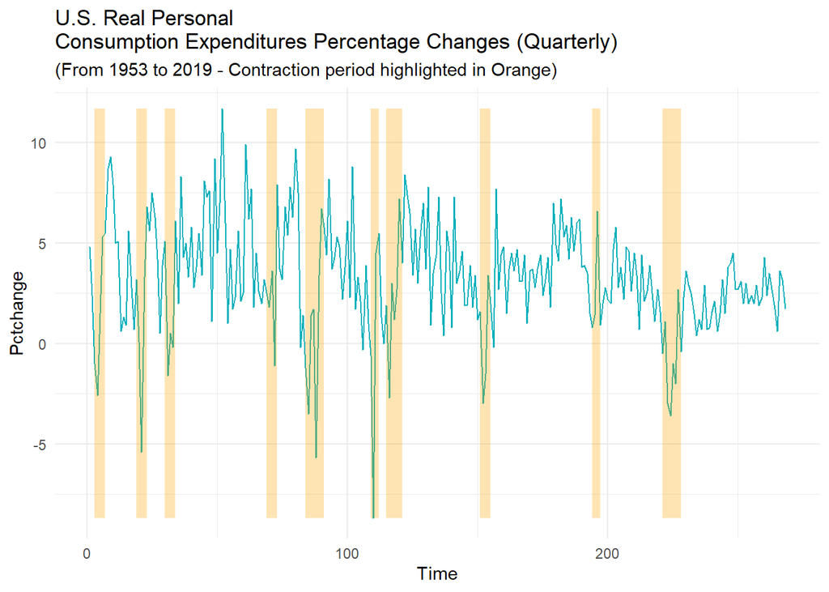

```r
set.seed(0)
dat <- consumption

## Determine highlighted regions
v <- dat$rects

## Get the start and end points for highlighted regions
inds <- diff(c(0, v))
#print(v)
start <- dat$Time[inds == 1]
end <- dat$Time[inds == -1]
if (length(start) > length(end)) end <- c(end, tail(dat$Time, 1))

## highlight region data
rects <- data.frame(start=start, end=end, group=seq_along(start))

ggplot(data=dat, aes(Time, Pctchange)) +
theme_minimal() +
geom_line(color = "#00AFBB", size = .5) +
geom_rect(data=rects, inherit.aes=FALSE, aes(xmin=start, xmax=end, ymin=min(dat$Pctchange),
ymax=max(dat$Pctchange), group=group), color="transparent", fill="orange",
alpha=0.3) +
labs(title = "U.S. Real Personal
Consumption Expenditures Percentage Changes (Quarterly)", subtitle = "(From 1953 to 2019 - Contraction period highlighted in Orange)")
```

(ii) Begin by identifying outliers and form dummies for them. [Form the dummies to have length 220, so they cover the time span from 1953.1 to 2007.4.]

**Discussion:** There are no new outliers that can be immediately seen from the plot. We do see a new low point during the 2009 recession but the drop is not so dramatic, as indicated by the percentage change points which is still over -5 (the previous outliers have percentage change points of either less than -5 or greater than 10). If our residuals later indicate that it is indeed an outlier we can refit.

```r
jan58<-rep(0, nrow(consumption))
oct65<-rep(0, nrow(consumption))
oct74<-rep(0, nrow(consumption))
apr80<-rep(0, nrow(consumption))

jan58[21] <- 1
oct65[52] <- 1
oct74[88] <- 1
apr80[110] <- 1

consumption$jan58 <- jan58
consumption$oct65 <- oct65
consumption$oct74 <- oct74
consumption$apr80 <- apr80
```

Fit an ARX model to the data covering the period 1953.1 to 2007.4. Explain how you arrived at your model fit.

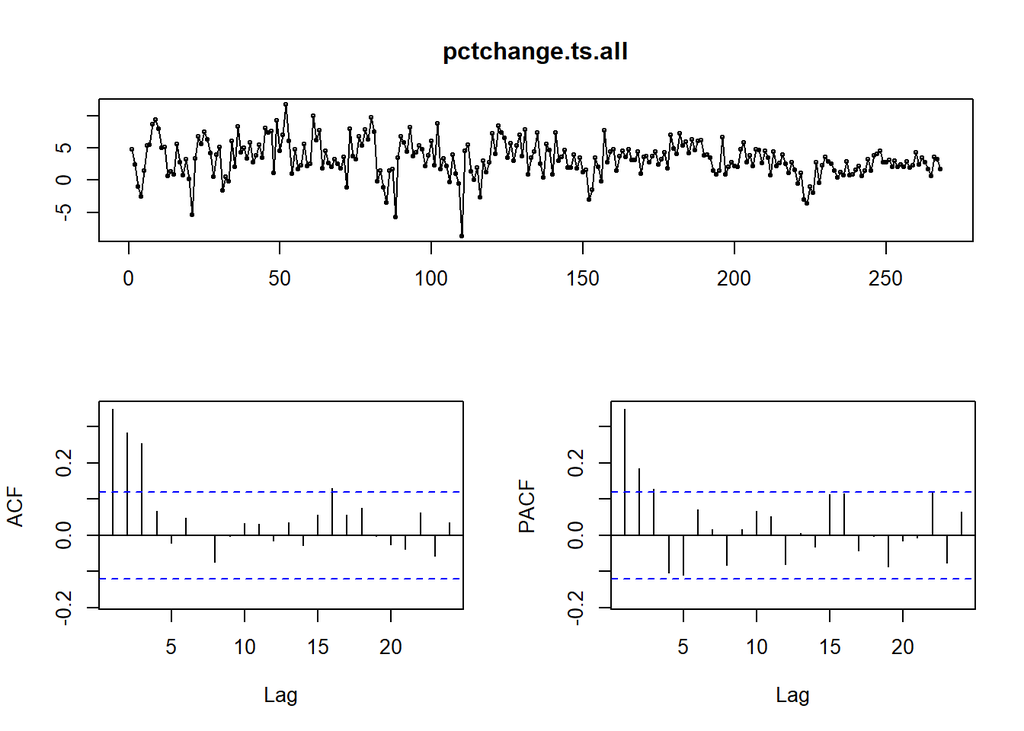

```r
pctchange.ts.all<-ts(consumption$Pctchange)
forecast::tsdisplay(pctchange.ts.all)
```

**Discussion:** We fit MA(3) and AR(3) models below, including the outliers AND using the entire consumption dataset. Bartlett’s test for both models show that white noise reduction was successfully achieved, however MA(3) has better/smaller AIC than AR(3) (AIC is 1202.46 for MA(3) and 1213.58 for AR(3)). Both models show that all four of the outlier variables are statistically significant.

The Coefficient test for AR(3) shows that it is an overfit model (the ar3 variable has a p-value of 0.35).

The ACF and PACF plot for the residuals of MA(3) model now shows that at lag 24 the line exceeds the blue threshold, however it is only slighlty exceeds the blue threshold so it is not necessarily critical that we add a variable to account for it.

We next try an ARMA(3,3), and MA(4) and AR(2) for comparison and see if they may provide a better fit.

```r
outliers<- consumption %>% select(jan58, oct65,oct74,apr80)
outliers<- as.matrix(outliers)
MA3.all<-Arima(pctchange.ts.all,order=c(0,0,3), xreg=outliers)
AR3.all<-Arima(pctchange.ts.all,order=c(3,0,0), xreg=outliers)
```

MA(3).all analysis

```r
summary(MA3.all)
```

```
## Series: pctchange.ts.all
## Regression with ARIMA(0,0,3) errors
##
## Coefficients:
##          ma1     ma2     ma3  intercept    jan58   oct65    oct74     apr80
##       0.2257  0.3851  0.2979     3.3677  -7.4515  6.2100  -8.9976  -12.6660
## s.e.  0.0596  0.0583  0.0580     0.2563   2.0185  2.0141   1.9671    1.9774
##
## sigma^2 = 5.003:  log likelihood = -592.23
## AIC=1202.46   AICc=1203.16   BIC=1234.78
##
## Training set error measures:
##                        ME     RMSE      MAE  MPE MAPE      MASE        ACF1
## Training set -0.007967398 2.203086 1.724559 -Inf  Inf 0.7061146 0.008520978
```

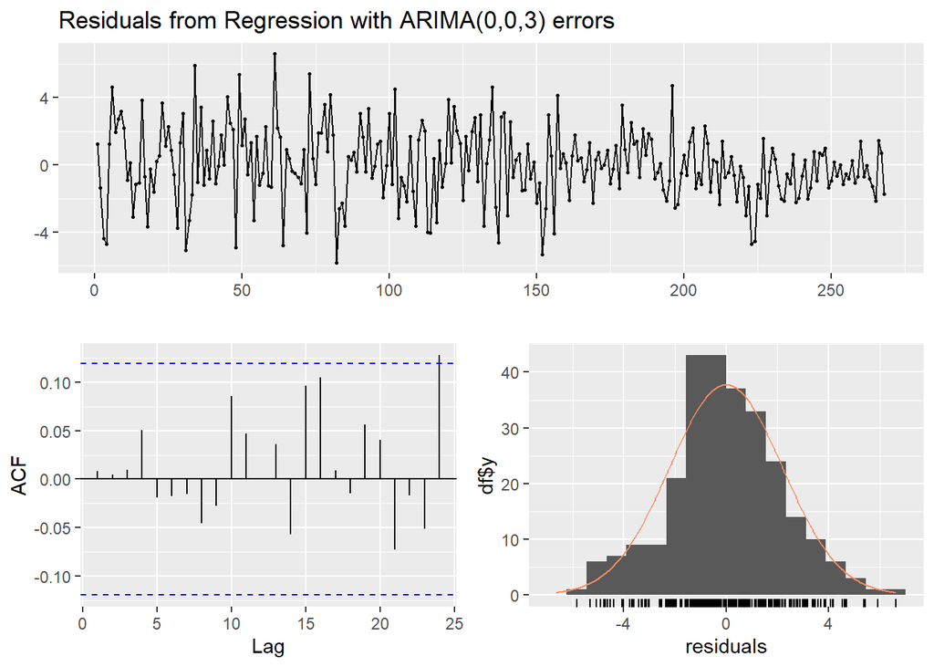

```
##
##  Ljung-Box test
##
## data:  Residuals from Regression with ARIMA(0,0,3) errors
## Q* = 4.498, df = 3, p-value = 0.2125
##
## Model df: 8.   Total lags used: 11
```

```r
checkresiduals(MA3.all)
```

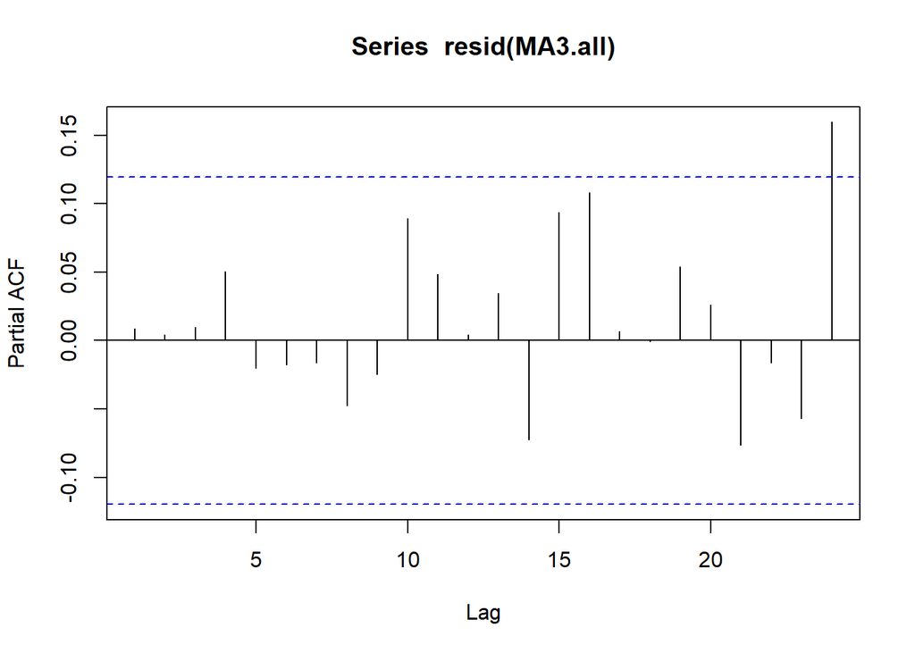

```r
pacf(resid(MA3.all))
```

```r
coeftest(MA3.all)
```

```
##
## z test of coefficients:
##
##             Estimate Std. Error z value  Pr(>|z|)
## ma1         0.225721   0.059625  3.7857 0.0001533 ***
## ma2         0.385061   0.058312  6.6034 4.018e-11 ***
## ma3         0.297876   0.057969  5.1386 2.769e-07 ***
## intercept   3.367744   0.256343 13.1376 < 2.2e-16 ***
## jan58      -7.451517   2.018525 -3.6916 0.0002229 ***
## oct65       6.210025   2.014069  3.0833 0.0020470 **
## oct74      -8.997600   1.967075 -4.5741 4.783e-06 ***
## apr80     -12.666013   1.977356 -6.4055 1.498e-10 ***
## ---
## Signif. codes:  0 '***' 0.001 '**' 0.01 '*' 0.05 '.' 0.1 ' ' 1
```

```r
bartlettB.test(ts(resid(MA3.all)))
```

```
##
##  Bartlett B Test for white noise
##
## data:
## = 0.33371, p-value = 0.9999
```

AR3.all analysis

```r
summary(AR3.all)
```

```
## Series: pctchange.ts.all
## Regression with ARIMA(3,0,0) errors
##
## Coefficients:
##          ar1     ar2     ar3  intercept    jan58   oct65    oct74     apr80
##       0.2335  0.2711  0.0582     3.3466  -9.0298  7.3935  -8.9232  -11.5447
## s.e.  0.0616  0.0618  0.0623     0.3123   2.1378  2.1644   2.1351    2.1197
##
## sigma^2 = 5.219:  log likelihood = -597.79
## AIC=1213.58   AICc=1214.28   BIC=1245.9
##
## Training set error measures:
##                        ME     RMSE      MAE  MPE MAPE      MASE       ACF1
## Training set -0.001896552 2.250262 1.762955 -Inf  Inf 0.7218358 0.01093216
```

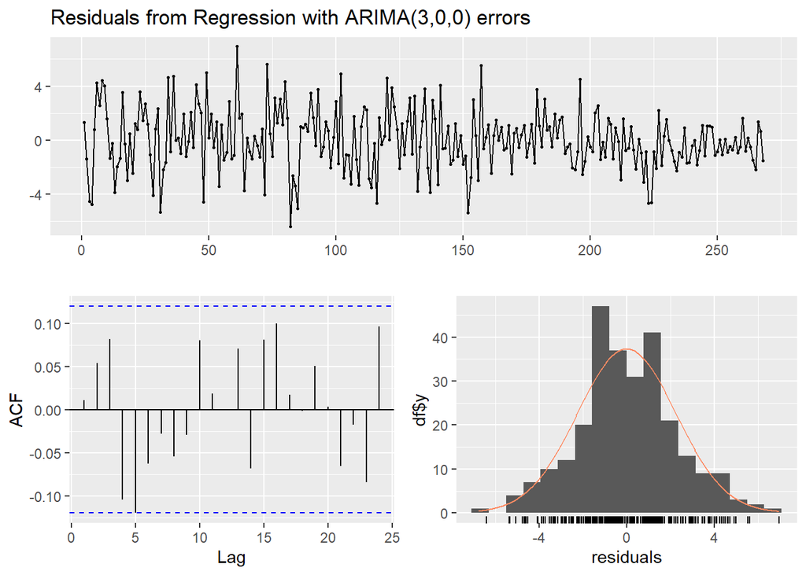

```
##
##  Ljung-Box test
##
## data:  Residuals from Regression with ARIMA(3,0,0) errors
## Q* = 13.841, df = 3, p-value = 0.00313
##
## Model df: 8.   Total lags used: 11
```

```r
checkresiduals(AR3.all)
```

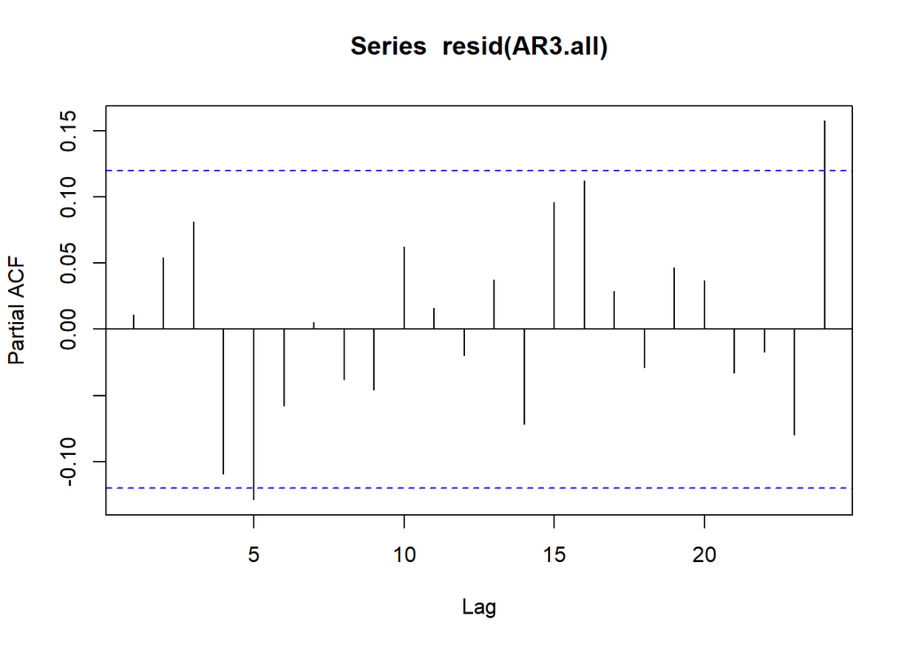

```r
pacf(resid(AR3.all))
```

```r
coeftest(AR3.all)
```

```
##
## z test of coefficients:
##
##             Estimate Std. Error z value  Pr(>|z|)
## ar1         0.233460   0.061644  3.7873 0.0001523 ***
## ar2         0.271122   0.061756  4.3902 1.132e-05 ***
## ar3         0.058220   0.062264  0.9350 0.3497650
## intercept   3.346593   0.312288 10.7164 < 2.2e-16 ***
## jan58      -9.029795   2.137824 -4.2238 2.402e-05 ***
## oct65       7.393459   2.164399  3.4159 0.0006356 ***
## oct74      -8.923239   2.135095 -4.1793 2.924e-05 ***
## apr80     -11.544735   2.119726 -5.4463 5.142e-08 ***
## ---
## Signif. codes:  0 '***' 0.001 '**' 0.01 '*' 0.05 '.' 0.1 ' ' 1
```

```r
bartlettB.test(ts(resid(AR3.all)))
```

```
##
##  Bartlett B Test for white noise
##
## data:
## = 0.70538, p-value = 0.7023
```

**Discussion:** MA(3) still is the best fit with the smallest AIC of 1202.46 after fitting ARMA(3,3), MA(4), and AR(2), with AICs of 1209.14, 1204.1, 1212.46 respectively. We see also in MA(4) that the added lags in the model are insignificant and thus overfit. MA(3) still has the smallest AIC so we will go forward in our analysis using this model.

```r
ARMA33.all<-Arima(pctchange.ts.all,order=c(3,0,3), xreg=outliers)
MA4.all<-Arima(pctchange.ts.all,order=c(0,0,4), xreg=outliers)
AR2.all<-Arima(pctchange.ts.all,order=c(2,0,0), xreg=outliers)
```

```r
summary(ARMA33.all)
```

```
## Series: pctchange.ts.all
## Regression with ARIMA(3,0,3) errors
##
## Coefficients:
##          ar1      ar2     ar3      ma1     ma2      ma3  intercept    jan58
##       1.3199  -0.6453  0.0843  -1.0987  0.7571  -0.2088     3.3716  -8.6502
## s.e.  0.6266   0.6072  0.2700   0.6228  0.4597   0.3675     0.2513   2.0705
##        oct65    oct74     apr80
##       7.4678  -9.1561  -12.5575
## s.e.  2.0198   2.0337    2.0324
##
## sigma^2 = 5.075:  log likelihood = -592.57
## AIC=1209.14   AICc=1210.37   BIC=1252.24
##
## Training set error measures:
##                        ME     RMSE      MAE  MPE MAPE      MASE        ACF1
## Training set -0.009005074 2.206117 1.745451 -Inf  Inf 0.7146685 0.001522748
```

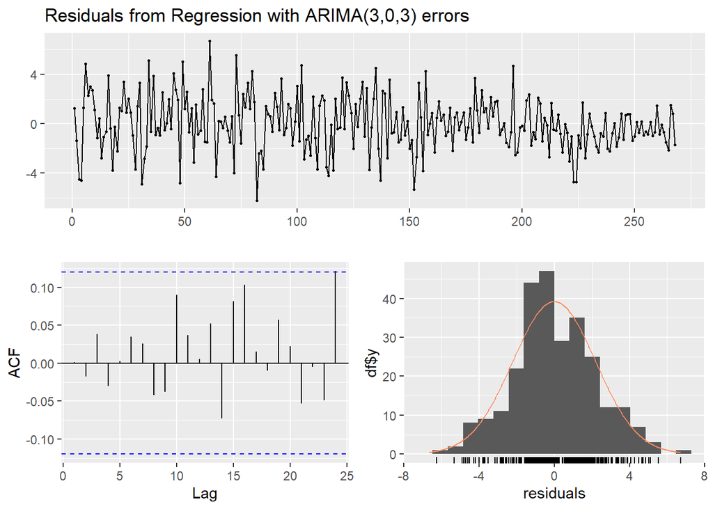

```
##
##  Ljung-Box test
##
## data:  Residuals from Regression with ARIMA(3,0,3) errors
## Q* = 7.0444, df = 3, p-value = 0.0705
##
## Model df: 11.   Total lags used: 14
```

```r
checkresiduals(ARMA33.all)
```

```r
coeftest(ARMA33.all)
```

```
##
## z test of coefficients:
##
##             Estimate Std. Error z value  Pr(>|z|)
## ar1         1.319897   0.626561  2.1066 0.0351544 *
## ar2        -0.645267   0.607183 -1.0627 0.2879073
## ar3         0.084346   0.269970  0.3124 0.7547143
## ma1        -1.098707   0.622789 -1.7642 0.0777030 .
## ma2         0.757114   0.459657  1.6471 0.0995313 .
## ma3        -0.208778   0.367490 -0.5681 0.5699535
## intercept   3.371604   0.251322 13.4155 < 2.2e-16 ***
## jan58      -8.650167   2.070468 -4.1779 2.942e-05 ***
## oct65       7.467840   2.019766  3.6974 0.0002178 ***
## oct74      -9.156082   2.033726 -4.5021 6.728e-06 ***
## apr80     -12.557453   2.032395 -6.1786 6.465e-10 ***
## ---
## Signif. codes:  0 '***' 0.001 '**' 0.01 '*' 0.05 '.' 0.1 ' ' 1
```

```r
summary(MA4.all)
```

```
## Series: pctchange.ts.all
## Regression with ARIMA(0,0,4) errors
##
## Coefficients:
##          ma1     ma2     ma3     ma4  intercept    jan58   oct65    oct74
##       0.2341  0.3927  0.2990  0.0408     3.3673  -7.6296  6.5676  -9.0241
## s.e.  0.0623  0.0616  0.0586  0.0679     0.2639   2.0467  2.1052   1.9769
##          apr80
##       -12.6048
## s.e.    1.9906
##
## sigma^2 = 5.016:  log likelihood = -592.05
## AIC=1204.1   AICc=1204.96   BIC=1240.01
##
## Training set error measures:
##                        ME     RMSE      MAE  MPE MAPE      MASE         ACF1
## Training set -0.008083565 2.201688 1.726284 -Inf  Inf 0.7068209 -0.001065762
```

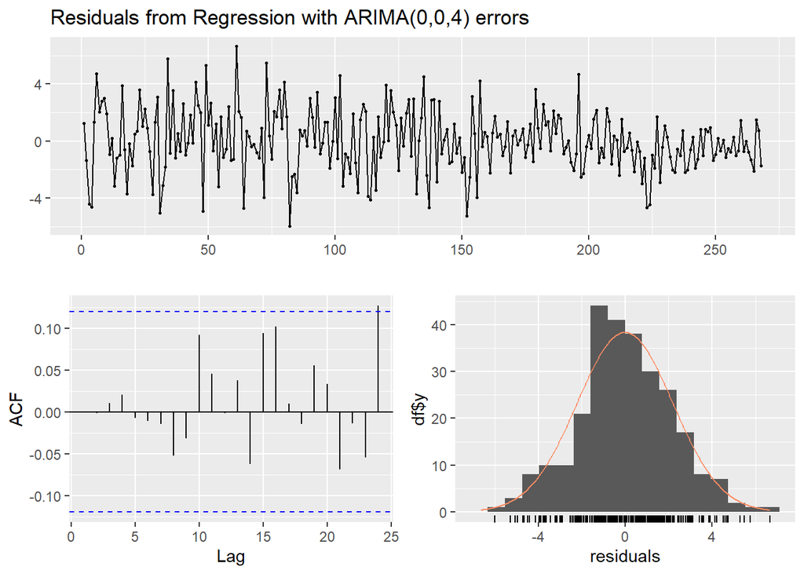

```
##
##  Ljung-Box test
##
## data:  Residuals from Regression with ARIMA(0,0,4) errors
## Q* = 4.2435, df = 3, p-value = 0.2363
##
## Model df: 9.   Total lags used: 12
```

```r
checkresiduals(MA4.all)
```

```r
coeftest(MA4.all)
```

```
##
## z test of coefficients:
##
##             Estimate Std. Error z value  Pr(>|z|)
## ma1         0.234121   0.062279  3.7592 0.0001704 ***
## ma2         0.392695   0.061594  6.3755 1.823e-10 ***
## ma3         0.298964   0.058631  5.0991 3.413e-07 ***
## ma4         0.040805   0.067923  0.6007 0.5480080
## intercept   3.367307   0.263874 12.7610 < 2.2e-16 ***
## jan58      -7.629620   2.046700 -3.7278 0.0001932 ***
## oct65       6.567581   2.105241  3.1196 0.0018108 **
## oct74      -9.024107   1.976893 -4.5648 5.000e-06 ***
## apr80     -12.604787   1.990642 -6.3320 2.420e-10 ***
## ---
## Signif. codes:  0 '***' 0.001 '**' 0.01 '*' 0.05 '.' 0.1 ' ' 1
```

```r
summary(AR2.all)
```

```
## Series: pctchange.ts.all
## Regression with ARIMA(2,0,0) errors
##
## Coefficients:
##          ar1     ar2  intercept    jan58   oct65    oct74     apr80
##       0.2492  0.2870     3.3493  -9.0651  7.6729  -9.1525  -11.5650
## s.e.  0.0593  0.0593     0.2953   2.1262  2.1311   2.1115    2.1106
##
## sigma^2 = 5.217:  log likelihood = -598.23
## AIC=1212.46   AICc=1213.01   BIC=1241.18
##
## Training set error measures:
##                        ME     RMSE      MAE  MPE MAPE      MASE      ACF1
## Training set -0.002765766 2.253968 1.770341 -Inf  Inf 0.7248599 -0.014931
```

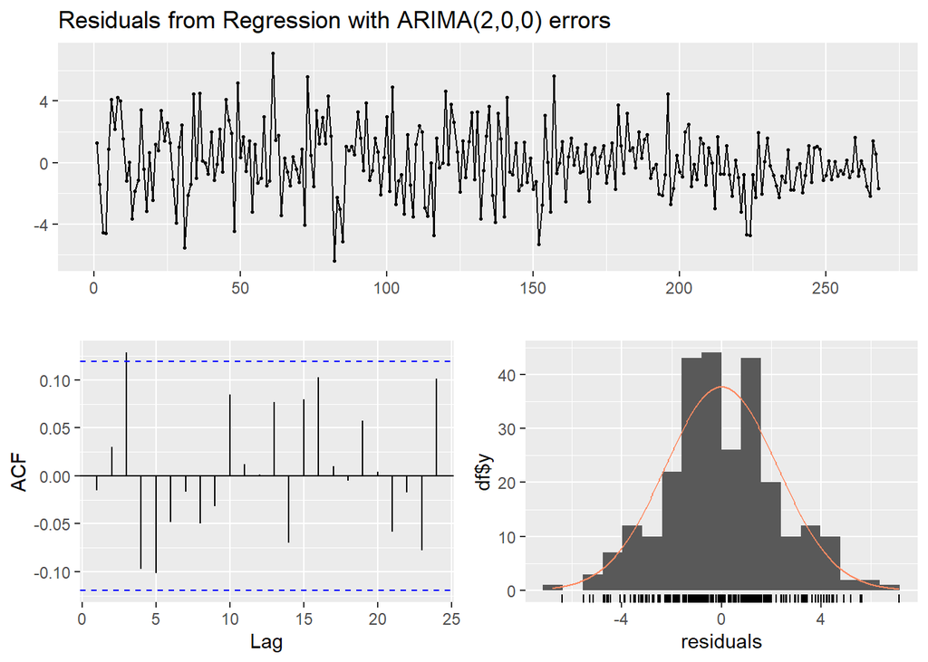

```
##
##  Ljung-Box test
##
## data:  Residuals from Regression with ARIMA(2,0,0) errors
## Q* = 13.956, df = 3, p-value = 0.002965
##
## Model df: 7.   Total lags used: 10
```

```r
checkresiduals(AR2.all)
```

```r
coeftest(AR2.all)
```

```
##
## z test of coefficients:
##
##             Estimate Std. Error z value  Pr(>|z|)
## ar1         0.249242   0.059275  4.2049 2.612e-05 ***
## ar2         0.286971   0.059257  4.8428 1.280e-06 ***
## intercept   3.349277   0.295330 11.3408 < 2.2e-16 ***
## jan58      -9.065080   2.126169 -4.2636 2.012e-05 ***
## oct65       7.672937   2.131084  3.6005 0.0003176 ***
## oct74      -9.152533   2.111454 -4.3347 1.460e-05 ***
## apr80     -11.564962   2.110630 -5.4794 4.268e-08 ***
## ---
## Signif. codes:  0 '***' 0.001 '**' 0.01 '*' 0.05 '.' 0.1 ' ' 1
```

4. Examine the residuals to investigate whether your selected model has achieved reduction to white noise. For this purpose include in your discussion consideration of the residual autocorrelations and partial autocorrelations and the residual spectral density. Also examine and discuss the plot of the residuals vs. time. Perform Bartlett’s test to determine if the fit has produced reduction to white noise. [Bartlett’s test is described and its use is illustrated in the 28 March notes.]